# InSPIRe Vaginal Resistome R Notebook (3): Statistical analysis

Nassim Boutouchent

In this 3rd Notebook, we present the main statistical analyses of the study, focusing on the comparative diversity analysis across : (i) microbial Community State Type (CST) and (ii) Pregnancy related outcomes.

This notebook is subdivided into 3 sections : (1) statistical comparisons of α-diversity metrics (including PRDI); (2) β-diversity analyses of species, antibiotic resistance genes (ARGs), and mobile genetic elements (MGEs); (3) Differential abundance analysis using MaAsLin2

## load packages

```r
library(tidyverse)
library(tibble)
library(dplyr)
library(reporttools)
library(dunn.test)
library(glmmTMB)
library(emmeans)
library(DHARMa)
library(performance)
library(see)
library(vegan)
library(ggplot2)
library(Maaslin2)
```

## load data

```r
#metadata : clinical variables + CSTs for each sample
metadata <- read_csv("../data/inspire_VR_metadata.csv")

# diversity metrics (previously computed in "InSPIRe caginal resistome jupyter notebook (2)")
Taxo_adiv <- read_csv("../data/Output/Taxa_alpha.csv")
MGEs_adiv <- read_csv("../data/Output/MGE_alpha.csv")
ARGs_RF_adiv <- read_csv("../data/Output/ARG_alpha.csv")

# RPKM count tables
Taxo_count <- read.csv("../data/Norm/inspire_taxonomy_count_sp.csv",row.names = "Seq_ID" )
ARGs_count <- read.csv("../data/Norm/ARG_count_RF_RPKM_Gene.csv", row.names = "SampleID")
ARGs_count_class <- read.csv("../data/Norm/ARG_count_RF_RPKM_Class.csv", row.names = "SampleID")
MGEs_count <- read.csv("../data/Norm/MGE_count_RF_RPKM_Gene.csv", row.names = "SampleID")
MGEs_count_family <- read.csv("../data/Norm/MGE_count_RF_RPKM_FamilyClean.csv", row.names = "SampleID")
```

# (1) a-diversity metrics comparison

```r
#Format data
format_adiv <- function(adiv_df, metadata_df, metric_col) {
  rownames(adiv_df) <- adiv_df$SampleID
  df <- metadata_df[rownames(adiv_df), , drop = FALSE]
  df[[metric_col]] <- adiv_df[[metric_col]]
  df}

# (1) global comparison (KW and Dunn's post hoc test)
# objective: determine whether diversity depends on global vaginal microbial composition,
# this analysis was performed using one sample per patient (n = 1,547) rather than 1,957 samples
# in order to satisfy the assumption of independence of observations.
compute_univ <- function(data, y, group, group_levels, patient_col) {

  df <- data[, c(y, group, patient_col), drop = FALSE]
  df <- df[!duplicated(df[[patient_col]]), , drop = FALSE]
  df[[group]] <- factor(df[[group]], levels = group_levels)
  kw <- kruskal.test(as.formula(paste(y, "~", group)), data = df)
  dunn <- dunn.test::dunn.test(x = df[[y]],
                               g = df[[group]],
                               method = "bh",
                               kw = FALSE,
                               list = TRUE)
  list(data = df,
       n_by_group = table(df[[group]]),
       kruskal = kw,
       dunn = dunn)}

# (2) comparison of genes Detection frequency  (Chi-square and pairwise fisher tests)
compute_prop <- function(df_abun, metadata, group, group_levels) {
  samp <- rownames(df_abun)
  df <- metadata[samp, , drop = FALSE]
  df <- df[, group, drop = FALSE]
  df[[group]] <- factor(df[[group]], levels = group_levels)

  detected <- ifelse(rowSums(df_abun > 0, na.rm = TRUE) > 0, 1, 0)
  df$detected <- detected
  df <- df[complete.cases(df), , drop = FALSE]
  tab <- table(df[[group]], df$detected)

  chisq <- chisq.test(tab)
  fisher <- pairwise.fisher.test(x = df$detected, g = df[[group]],p.adjust.method = "BH")
  prop <- prop.table(tab, margin = 1)

  list(df = df,
       table = tab,
       proportion = prop,
       chisq = chisq,
       fisher = fisher)
}
```

## (a) Comparison across CTs

Comparison of Intra-sample diversity metrics for species, ARGs and MGEs across CSTs

```r
metadata_df <- as.data.frame(metadata)
rownames(metadata_df) <- metadata_df$SampleID
metadata_unique <- metadata_df[!duplicated(metadata_df$PATIENT), , drop = FALSE]
cst_levels <- c("CST I", "CST II", "CST III", "CST IV", "CST V")

# Test whether ARGs/MGE intra-sample diversity metrics are independent of the VM microbial profile
df_tax_shannon <- format_adiv(adiv_df = Taxo_adiv,
                              metadata_df = metadata_unique,
                              metric_col  = "Shannon")

res_tax_shannon <- compute_univ(data = df_tax_shannon,
                                y = "Shannon",
                                group = "CST",
                                group_levels = cst_levels,
                                patient_col  = "PATIENT")
```

```
##
##                            Comparison of x by group
##                              (Benjamini-Hochberg)
## Col Mean-|
## Row Mean |      CST I     CST II    CST III     CST IV
## ---------+--------------------------------------------
##   CST II |  -10.48307
##          |    0.0000*
##  CST III |  -5.000912   7.101427
##          |    0.0000*    0.0000*
##   CST IV |  -17.52028  -0.847223  -11.71529
##          |    0.0000*     0.2205    0.0000*
##    CST V |  -8.474600   0.664408  -5.545511   1.551081
##          |    0.0000*     0.2532    0.0000*     0.0756
##
##
## List of pairwise comparisons: Z statistic (adjusted p-value)
## --------------------------------------
## CST I - CST II   : -10.48307 (0.0000)*
## CST I - CST III  : -5.000912 (0.0000)*
## CST II - CST III :  7.101427 (0.0000)*
## CST I - CST IV   : -17.52028 (0.0000)*
## CST II - CST IV  : -0.847223 (0.2205)
## CST III - CST IV : -11.71529 (0.0000)*
## CST I - CST V    : -8.474600 (0.0000)*
## CST II - CST V   :  0.664408 (0.2532)
## CST III - CST V  : -5.545511 (0.0000)*
## CST IV - CST V   :  1.551081 (0.0756)
##
## alpha = 0.05
## Reject Ho if p <= alpha/2
```

```r
res_tax_shannon$kruskal
```

```
##
##  Kruskal-Wallis rank sum test
##
## data:  Shannon by CST
## Kruskal-Wallis chi-squared = 380.66, df = 4, p-value < 2.2e-16
```

```r
res_tax_shannon$dunn
```

```
## $chi2
## [1] 380.6616
##
## $Z
##  [1] -10.4830720  -5.0009125   7.1014279 -17.5202832  -0.8472233 -11.7153000
##  [7]  -8.4746008   0.6644081  -5.5455115   1.5510813
##
## $P
##  [1] 5.166582e-26 2.852981e-07 6.173723e-13 5.016235e-69 1.984353e-01
##  [6] 5.320696e-32 1.179435e-17 2.532146e-01 1.465480e-08 6.044110e-02
##
## $P.adjusted
##  [1] 1.722194e-25 4.075687e-07 1.234745e-12 5.016235e-68 2.204837e-01
##  [6] 2.660348e-31 2.948588e-17 2.532146e-01 2.442467e-08 7.555137e-02
##
## $comparisons
##  [1] "CST I - CST II"   "CST I - CST III"  "CST II - CST III" "CST I - CST IV"
##  [5] "CST II - CST IV"  "CST III - CST IV" "CST I - CST V"    "CST II - CST V"
##  [9] "CST III - CST V"  "CST IV - CST V"
```

```r
print(res_tax_shannon$n_by_group)
```

```
##
##   CST I  CST II CST III  CST IV   CST V
##     595     111     403     354      84
```

```r
df_tax_pd <- format_adiv(adiv_df = Taxo_adiv,
                         metadata_df = metadata_unique,
                         metric_col  = "PD")

res_tax_pd <- compute_univ(data = df_tax_pd,
                           y = "PD",
                           group = "CST",
                           group_levels = cst_levels,
                           patient_col  = "PATIENT")
```

```
##
##                            Comparison of x by group
##                              (Benjamini-Hochberg)
## Col Mean-|
## Row Mean |      CST I     CST II    CST III     CST IV
## ---------+--------------------------------------------
##   CST II |  -2.710610
##          |    0.0056*
##  CST III |  -4.413941  -0.042061
##          |    0.0000*     0.4832
##   CST IV |  -9.221821  -3.113945  -4.588400
##          |    0.0000*    0.0018*    0.0000*
##    CST V |  -1.958148   0.359693   0.471277   3.219721
##          |     0.0359     0.3995     0.3984    0.0016*
##
##
## List of pairwise comparisons: Z statistic (adjusted p-value)
## --------------------------------------
## CST I - CST II   : -2.710610 (0.0056)*
## CST I - CST III  : -4.413941 (0.0000)*
## CST II - CST III : -0.042061 (0.4832)
## CST I - CST IV   : -9.221821 (0.0000)*
## CST II - CST IV  : -3.113945 (0.0018)*
## CST III - CST IV : -4.588400 (0.0000)*
## CST I - CST V    : -1.958148 (0.0359)
## CST II - CST V   :  0.359693 (0.3995)
## CST III - CST V  :  0.471277 (0.3984)
## CST IV - CST V   :  3.219721 (0.0016)*
##
## alpha = 0.05
## Reject Ho if p <= alpha/2
```

```r
res_tax_pd$kruskal
```

```
##
##  Kruskal-Wallis rank sum test
##
## data:  PD by CST
## Kruskal-Wallis chi-squared = 86.012, df = 4, p-value < 2.2e-16
```

```r
res_tax_pd$dunn
```

```
## $chi2
## [1] 86.01217
##
## $Z
##  [1] -2.71061024 -4.41394171 -0.04206193 -9.22182175 -3.11394597 -4.58840043
##  [7] -1.95814864  0.35969327  0.47127782  3.21972142
##
## $P
##  [1] 3.357976e-03 5.075265e-06 4.832247e-01 1.460474e-20 9.230165e-04
##  [6] 2.233276e-06 2.510629e-02 3.595383e-01 3.187212e-01 6.415761e-04
##
## $P.adjusted
##  [1] 5.596627e-03 1.691755e-05 4.832247e-01 1.460474e-19 1.846033e-03
##  [6] 1.116638e-05 3.586612e-02 3.994870e-01 3.984015e-01 1.603940e-03
##
## $comparisons
##  [1] "CST I - CST II"   "CST I - CST III"  "CST II - CST III" "CST I - CST IV"
##  [5] "CST II - CST IV"  "CST III - CST IV" "CST I - CST V"    "CST II - CST V"
##  [9] "CST III - CST V"  "CST IV - CST V"
```

```r
print(res_tax_pd$n_by_group)
```

```
##
##   CST I  CST II CST III  CST IV   CST V
##     595     111     403     354      84
```

```r
df_mge_shannon <- format_adiv(adiv_df = MGEs_adiv,
                              metadata_df = metadata_unique,
                              metric_col  = "Shannon")

res_mge_shannon <- compute_univ(data = df_mge_shannon,
                                y = "Shannon",
                                group = "CST",
                                group_levels = cst_levels,
                                patient_col  = "PATIENT")
```

```
##
##                            Comparison of x by group
##                              (Benjamini-Hochberg)
## Col Mean-|
## Row Mean |      CST I     CST II    CST III     CST IV
## ---------+--------------------------------------------
##   CST II |  -1.109359
##          |     0.1485
##  CST III |  -16.33893  -8.763545
##          |    0.0000*    0.0000*
##   CST IV |  -7.605999  -3.638800   7.461855
##          |    0.0000*    0.0002*    0.0000*
##    CST V |  -2.347885  -1.099213   6.506707   1.951771
##          |    0.0135*     0.1358    0.0000*     0.0319
##
##
## List of pairwise comparisons: Z statistic (adjusted p-value)
## --------------------------------------
## CST I - CST II   : -1.109359 (0.1485)
## CST I - CST III  : -16.33893 (0.0000)*
## CST II - CST III : -8.763545 (0.0000)*
## CST I - CST IV   : -7.605999 (0.0000)*
## CST II - CST IV  : -3.638800 (0.0002)*
## CST III - CST IV :  7.461855 (0.0000)*
## CST I - CST V    : -2.347885 (0.0135)*
## CST II - CST V   : -1.099213 (0.1358)
## CST III - CST V  :  6.506707 (0.0000)*
## CST IV - CST V   :  1.951771 (0.0319)
##
## alpha = 0.05
## Reject Ho if p <= alpha/2
```

```r
res_mge_shannon$kruskal
```

```
##
##  Kruskal-Wallis rank sum test
##
## data:  Shannon by CST
## Kruskal-Wallis chi-squared = 281.99, df = 4, p-value < 2.2e-16
```

```r
res_mge_shannon$dunn
```

```
## $chi2
## [1] 281.9931
##
## $Z
##  [1]  -1.109359 -16.338936  -8.763546  -7.606000  -3.638801   7.461856
##  [7]  -2.347885  -1.099214   6.506708   1.951771
##
## $P
##  [1] 1.336377e-01 2.607744e-60 9.460144e-19 1.413549e-14 1.369553e-04
##  [6] 4.265618e-14 9.440169e-03 1.358375e-01 3.840780e-11 2.548268e-02
##
## $P.adjusted
##  [1] 1.484863e-01 2.607744e-59 4.730072e-18 4.711831e-14 2.282588e-04
##  [6] 1.066404e-13 1.348596e-02 1.358375e-01 7.681560e-11 3.185335e-02
##
## $comparisons
##  [1] "CST I - CST II"   "CST I - CST III"  "CST II - CST III" "CST I - CST IV"
##  [5] "CST II - CST IV"  "CST III - CST IV" "CST I - CST V"    "CST II - CST V"
##  [9] "CST III - CST V"  "CST IV - CST V"
```

```r
print(res_mge_shannon$n_by_group)
```

```
##
##   CST I  CST II CST III  CST IV   CST V
##     595     111     403     354      84
```

```r
df_arg_shannon <- format_adiv(adiv_df = ARGs_RF_adiv,
                              metadata_df = metadata_unique,
                              metric_col  = "Shannon")

res_arg_shannon <- compute_univ(data = df_arg_shannon,
                                y = "Shannon",
                                group = "CST",
                                group_levels = cst_levels,
                                patient_col  = "PATIENT")
```

```
##
##                            Comparison of x by group
##                              (Benjamini-Hochberg)
## Col Mean-|
## Row Mean |      CST I     CST II    CST III     CST IV
## ---------+--------------------------------------------
##   CST II |  -2.727637
##          |    0.0046*
##  CST III |  -12.65365  -4.984690
##          |    0.0000*    0.0000*
##   CST IV |  -10.20961  -3.707268   1.798849
##          |    0.0000*    0.0002*     0.0400
##    CST V |  -2.408426   0.008954   4.465650   3.333602
##          |    0.0100*     0.4964    0.0000*    0.0007*
##
##
## List of pairwise comparisons: Z statistic (adjusted p-value)
## --------------------------------------
## CST I - CST II   : -2.727637 (0.0046)*
## CST I - CST III  : -12.65365 (0.0000)*
## CST II - CST III : -4.984690 (0.0000)*
## CST I - CST IV   : -10.20961 (0.0000)*
## CST II - CST IV  : -3.707268 (0.0002)*
## CST III - CST IV :  1.798849 (0.0400)
## CST I - CST V    : -2.408426 (0.0100)*
## CST II - CST V   :  0.008954 (0.4964)
## CST III - CST V  :  4.465650 (0.0000)*
## CST IV - CST V   :  3.333602 (0.0007)*
##
## alpha = 0.05
## Reject Ho if p <= alpha/2
```

```r
res_arg_shannon$kruskal
```

```
##
##  Kruskal-Wallis rank sum test
##
## data:  Shannon by CST
## Kruskal-Wallis chi-squared = 196.57, df = 4, p-value < 2.2e-16
```

```r
res_arg_shannon$dunn
```

```
## $chi2
## [1] 196.5722
##
## $Z
##  [1]  -2.727637010 -12.653651512  -4.984690813 -10.209618474  -3.707268179
##  [6]   1.798849996  -2.408426628   0.008954319   4.465650158   3.333602669
##
## $P
##  [1] 3.189488e-03 5.339676e-37 3.103049e-07 8.978476e-25 1.047535e-04
##  [6] 3.602121e-02 8.010723e-03 4.964278e-01 3.991298e-06 4.286451e-04
##
## $P.adjusted
##  [1] 4.556411e-03 5.339676e-36 1.034350e-06 4.489238e-24 2.095070e-04
##  [6] 4.002356e-02 1.001340e-02 4.964278e-01 9.978245e-06 7.144085e-04
##
## $comparisons
##  [1] "CST I - CST II"   "CST I - CST III"  "CST II - CST III" "CST I - CST IV"
##  [5] "CST II - CST IV"  "CST III - CST IV" "CST I - CST V"    "CST II - CST V"
##  [9] "CST III - CST V"  "CST IV - CST V"
```

```r
print(res_arg_shannon$n_by_group)
```

```
##
##   CST I  CST II CST III  CST IV   CST V
##     595     111     403     354      84
```

```r
df_arg_prdi <- format_adiv(adiv_df = ARGs_RF_adiv,
                           metadata_df = metadata_unique,
                           metric_col  = "PD")

res_arg_prdi <- compute_univ(data = df_arg_prdi,
                             y = "PD", group = "CST",
                             group_levels = cst_levels,
                             patient_col  = "PATIENT")
```

```
##
##                            Comparison of x by group
##                              (Benjamini-Hochberg)
## Col Mean-|
## Row Mean |      CST I     CST II    CST III     CST IV
## ---------+--------------------------------------------
##   CST II |  -3.807189
##          |    0.0001*
##  CST III |  -16.84022  -6.463110
##          |    0.0000*    0.0000*
##   CST IV |  -13.19467  -4.523115   2.756044
##          |    0.0000*    0.0000*    0.0033*
##    CST V |  -3.007534   0.297898   6.135308   4.409168
##          |    0.0016*     0.3829    0.0000*    0.0000*
##
##
## List of pairwise comparisons: Z statistic (adjusted p-value)
## --------------------------------------
## CST I - CST II   : -3.807189 (0.0001)*
## CST I - CST III  : -16.84022 (0.0000)*
## CST II - CST III : -6.463110 (0.0000)*
## CST I - CST IV   : -13.19467 (0.0000)*
## CST II - CST IV  : -4.523115 (0.0000)*
## CST III - CST IV :  2.756044 (0.0033)*
## CST I - CST V    : -3.007534 (0.0016)*
## CST II - CST V   :  0.297898 (0.3829)
## CST III - CST V  :  6.135308 (0.0000)*
## CST IV - CST V   :  4.409168 (0.0000)*
##
## alpha = 0.05
## Reject Ho if p <= alpha/2
```

```r
res_arg_prdi$kruskal
```

```
##
##  Kruskal-Wallis rank sum test
##
## data:  PD by CST
## Kruskal-Wallis chi-squared = 341.45, df = 4, p-value < 2.2e-16
```

```r
res_arg_prdi$dunn
```

```
## $chi2
## [1] 341.4475
##
## $Z
##  [1]  -3.8071896 -16.8402219  -6.4631106 -13.1946753  -4.5231155   2.7560443
##  [7]  -3.0075348   0.2978985   6.1353082   4.4091684
##
## $P
##  [1] 7.027750e-05 6.188573e-64 5.128614e-11 4.707985e-40 3.046798e-06
##  [6] 2.925253e-03 1.316880e-03 3.828903e-01 4.249713e-10 5.188415e-06
##
## $P.adjusted
##  [1] 1.003964e-04 6.188573e-63 1.709538e-10 2.353993e-39 6.093596e-06
##  [6] 3.250282e-03 1.646100e-03 3.828903e-01 1.062428e-09 8.647359e-06
##
## $comparisons
##  [1] "CST I - CST II"   "CST I - CST III"  "CST II - CST III" "CST I - CST IV"
##  [5] "CST II - CST IV"  "CST III - CST IV" "CST I - CST V"    "CST II - CST V"
##  [9] "CST III - CST V"  "CST IV - CST V"
```

```r
print(res_arg_prdi$n_by_group)
```

```
##
##   CST I  CST II CST III  CST IV   CST V
##     595     111     403     354      84
```

```r
#test if ARGs/MGEs detection frequency is linked to CST groups
arg_detect_cst <- compute_prop(df_abun = ARGs_count, metadata = metadata_df, group = "CST",
                                    group_levels = c("CST I", "CST II", "CST III", "CST IV", "CST V"))
arg_detect_cst$chisq
```

```
##
##  Pearson's Chi-squared test
##
## data:  tab
## X-squared = 593.01, df = 4, p-value < 2.2e-16
```

```r
arg_detect_cst$fisher
```

```
##
##  Pairwise comparisons using
##
## data:  df$detected and df[[group]]
##
##         CST I   CST II  CST III CST IV
## CST II  2.8e-10 -       -       -
## CST III < 2e-16 < 2e-16 -       -
## CST IV  < 2e-16 1.2e-06 3.3e-09 -
## CST V   1.2e-06 0.61    < 2e-16 1.2e-06
##
## P value adjustment method: BH
```

```r
arg_detect_cst$table
```

```
##
##             0   1
##   CST I   566 184
##   CST II   70  76
##   CST III  55 454
##   CST IV  115 332
##   CST V    54  51
```

```r
arg_detect_cst$proportion
```

```
##
##                   0         1
##   CST I   0.7546667 0.2453333
##   CST II  0.4794521 0.5205479
##   CST III 0.1080550 0.8919450
##   CST IV  0.2572707 0.7427293
##   CST V   0.5142857 0.4857143
```

```r
mge_detect_cst <- compute_prop(df_abun = MGEs_count, metadata = metadata_df, group = "CST",
                                    group_levels = c("CST I", "CST II", "CST III", "CST IV", "CST V"))
mge_detect_cst$chisq
```

```
##
##  Pearson's Chi-squared test
##
## data:  tab
## X-squared = 263.96, df = 4, p-value < 2.2e-16
```

```r
mge_detect_cst$fisher
```

```
##
##  Pairwise comparisons using
##
## data:  df$detected and df[[group]]
##
##         CST I   CST II  CST III CST IV
## CST II  9.8e-07 -       -       -
## CST III < 2e-16 0.00024 -       -
## CST IV  < 2e-16 0.00105 0.65207 -
## CST V   0.04029 0.08014 8.4e-08 6.0e-07
##
## P value adjustment method: BH
```

```r
mge_detect_cst$table
```

```
##
##             0   1
##   CST I   475 275
##   CST II   59  87
##   CST III 122 387
##   CST IV  113 334
##   CST V    55  50
```

```r
mge_detect_cst$proportion
```

```
##
##                   0         1
##   CST I   0.6333333 0.3666667
##   CST II  0.4041096 0.5958904
##   CST III 0.2396857 0.7603143
##   CST IV  0.2527964 0.7472036
##   CST V   0.5238095 0.4761905
```

## (b) For Pregnancy related clinical outcomes

We fitted a linear mixed-effects models (GLMMs) to investigate associations while adjusting for covariates and accounting for repeated measures (patient ID).

Firstly, we constructed a univariate models, accounting for repeated measures to reflect the overall distribution.

We subsequently built a multivariate models to estimate the independent contribution of each variable

*Note* *Only clinical variables that significantly differed across clinical groups were included in the multivariate models (See supplementary tables).*

**Variables dictionary:** `BIL_INC_ATB` (Antibiotics): antibiotic exposure during pregnancy `PAT_AGE` (Age): maternal age `IMC` (BMI): body mass index `CERCLAGE` (Cervical cerclage) `RCIU` (IUGR): intrauterine growth restriction `DIABET_GESTA` (Gestational diabetes) `HTA_PRE_ECLAM` (Hypertension / preeclampsia): hypertensive disorders of pregnancy

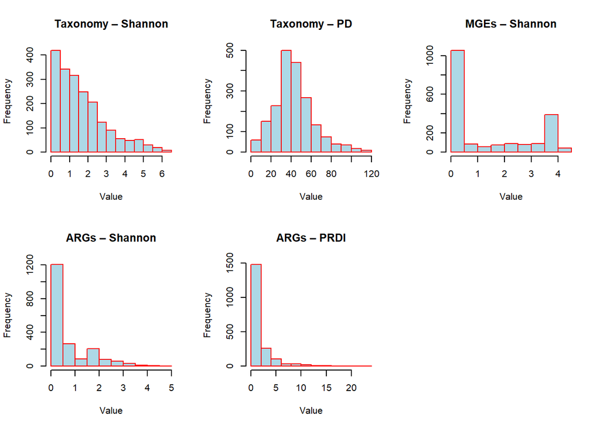

```r
# to better guide the choice of an appropriate statistical model, we first visualize the distribution of a-div metrics
par(mfrow = c(2, 3))
hist(Taxo_adiv$Shannon,main = "Taxonomy – Shannon",xlab = "Value",col = "lightblue",border = "red")
hist(Taxo_adiv$PD,main = "Taxonomy – PD", xlab = "Value", col = "lightblue",border = "red")
hist(MGEs_adiv$Shannon, main = "MGEs – Shannon", xlab = "Value", col = "lightblue", border = "red")
hist(ARGs_RF_adiv$Shannon,main = "ARGs – Shannon",xlab = "Value",col = "lightblue",border = "red")
hist(ARGs_RF_adiv$PD,main = "ARGs – PRDI", xlab = "Value",col = "lightblue",border = "red")

# Given that ARG and MGE diversity metrics are zero-inflated and
# that zero values represent biologically meaningful information, these metrics will be analyzed using hurdle models (binomial + Gaussian).
# This approach allows a biologically coherent analysis of presence/absence, followed by composition when present
# Species diversity metrics will be analyzed using a Gaussian model (Log transformed) (see model performance)
```

### GLMMs models construction

```r
#Gaussian model
run_glmm_gauss <- function(adiv_df, metadata_df, response, family,
                           fixed_effect, covariates = NULL, random_effect,
                           transform, reference) {
  names(adiv_df)[1] <- "SampleID"
  adiv_df$SampleID <- as.character(adiv_df$SampleID)
  metadata_df$SampleID <- as.character(metadata_df$SampleID)

  keep_meta <- c("SampleID", fixed_effect, covariates, random_effect)
  keep_meta <- keep_meta[!is.na(keep_meta) & keep_meta != ""]
  keep_meta <- unique(keep_meta)

  df <- merge(adiv_df, metadata_df[, keep_meta, drop = FALSE], by = "SampleID")

  df[[fixed_effect]] <- factor(df[[fixed_effect]])
  if (!is.null(reference)) df[[fixed_effect]] <- relevel(df[[fixed_effect]], ref = reference)

  df$resp <- transform(df[[response]])
  df <- df[complete.cases(df[, c("resp", fixed_effect, covariates, random_effect), drop = FALSE]), , drop = FALSE]

  rhs_full <- paste(c(fixed_effect, covariates, paste0("(1|", random_effect, ")")), collapse = " + ")
  mod_full <- glmmTMB(as.formula(paste("resp ~", rhs_full)), data = df, family = family)
  emm <- emmeans(mod_full, fixed_effect)
  pw  <- as.data.frame(pairs(emm, adjust = "tukey"))

  list(df = df, mod_full = mod_full, pairs = pw)}
```

```r
#hurdle model (binomial + gaussian)
run_glmm_hurdle <- function(adiv_df, metadata_df, response,
                            fixed_effect, covariates = NULL,
                            random_effect, reference, presence_col) {
  # Format data (drop NaN values, as the # of NaN are negligible)
  keep_meta <- c("SampleID", fixed_effect, covariates, random_effect)
  keep_meta <- keep_meta[!is.na(keep_meta) & keep_meta != ""]
  keep_meta <- unique(keep_meta)
  df <- merge(adiv_df, metadata_df[, keep_meta, drop = FALSE], by = "SampleID")

  df[[fixed_effect]] <- factor(df[[fixed_effect]])
  df[[fixed_effect]] <- relevel(df[[fixed_effect]], ref = reference)

  df$y <- df[[response]]
  df <- df[complete.cases(
    df[, c("y", presence_col, fixed_effect, covariates, random_effect),
       drop = FALSE]), , drop = FALSE]

  df$detected <- df[[presence_col]]

  rhs <- paste(c(fixed_effect, covariates, paste0("(1|", random_effect, ")")),
               collapse = " + ")
#model
  mod_det <- glmmTMB(as.formula(paste("detected ~", rhs)),
                     data = df,family = binomial())

  # PART II : conditional (gaussian) ---> + samples
  df_pos <- df[df[[presence_col]] == 1, , drop = FALSE]
  df_pos$resp <- log1p(df_pos$y)

  mod_cont <- glmmTMB(
    as.formula(paste("resp ~", rhs)),
    data = df_pos,
    family = gaussian()
  )

  #  contrasts
  emm_det <- emmeans(mod_det, specs = fixed_effect, type = "response")
  pairs_det <- pairs(emm_det, adjust = "tukey")

  emm_cont <- emmeans(mod_cont, specs = fixed_effect)
  pairs_cont <- pairs(emm_cont, adjust = "tukey")

  list(
    df_all = df,
    df_pos = df_pos,
    mod_detection = mod_det,
    mod_conditional = mod_cont,
    emm_detection = emm_det,
    tukey_detection = pairs_det,
    emm_conditional = emm_cont,
    tukey_conditional = pairs_cont
  )}
```

#### Univariate analysis

```r
#GLMMs gaussian model for species a-div metrics

#Shannon
res_tax_shannon_uni <- run_glmm_gauss(
  adiv_df = Taxo_adiv,
  metadata_df = metadata_df,
  response = "Shannon",
  family = gaussian(),
  fixed_effect = "OUT_GROUP",
  random_effect = "PATIENT",
  transform = log1p,
  reference = "A"
)

# phylogenetic ddiversity (PD)
res_tax_PD_uni <- run_glmm_gauss(
  adiv_df = Taxo_adiv,
  metadata_df = metadata_df,
  response = "PD",
  family = gaussian(),
  fixed_effect = "OUT_GROUP",
  random_effect = "PATIENT",
  transform = log1p,
  reference = "A"
)

summary(res_tax_shannon_uni$mod_full)
```

```
##  Family: gaussian  ( identity )
## Formula:          resp ~ OUT_GROUP + (1 | PATIENT)
## Data: df
##
##       AIC       BIC    logLik -2*log(L)  df.resid
##    2511.6    2545.1   -1249.8    2499.6      1951
##
## Random effects:
##
## Conditional model:
##  Groups   Name        Variance Std.Dev.
##  PATIENT  (Intercept) 0.07869  0.2805
##  Residual             0.13766  0.3710
## Number of obs: 1957, groups:  PATIENT, 1547
##
## Dispersion estimate for gaussian family (sigma^2): 0.138
##
## Conditional model:
##              Estimate Std. Error z value Pr(>|z|)
## (Intercept)  0.824829   0.019996   41.25  < 2e-16 ***
## OUT_GROUPB  -0.034060   0.031954   -1.07    0.286
## OUT_GROUPC   0.007326   0.030274    0.24    0.809
## OUT_GROUPD   0.180597   0.030052    6.01 1.86e-09 ***
## ---
## Signif. codes:  0 '***' 0.001 '**' 0.01 '*' 0.05 '.' 0.1 ' ' 1
```

```r
res_tax_shannon_uni$pairs
```

```
##  contrast    estimate         SE   df t.ratio p.value
##  A - B     0.03405987 0.03195417 1951   1.066  0.7104
##  A - C    -0.00732601 0.03027389 1951  -0.242  0.9950
##  A - D    -0.18059665 0.03005199 1951  -6.009  <.0001
##  B - C    -0.04138588 0.03373327 1951  -1.227  0.6098
##  B - D    -0.21465652 0.03353425 1951  -6.401  <.0001
##  C - D    -0.17327064 0.03193526 1951  -5.426  <.0001
##
## P value adjustment: tukey method for comparing a family of 4 estimates
```

```r
summary(res_tax_PD_uni$mod_full)
```

```
##  Family: gaussian  ( identity )
## Formula:          resp ~ OUT_GROUP + (1 | PATIENT)
## Data: df
##
##       AIC       BIC    logLik -2*log(L)  df.resid
##    2900.6    2934.1   -1444.3    2888.6      1951
##
## Random effects:
##
## Conditional model:
##  Groups   Name        Variance Std.Dev.
##  PATIENT  (Intercept) 0.08359  0.2891
##  Residual             0.17843  0.4224
## Number of obs: 1957, groups:  PATIENT, 1547
##
## Dispersion estimate for gaussian family (sigma^2): 0.178
##
## Conditional model:
##             Estimate Std. Error z value Pr(>|z|)
## (Intercept)  3.57462    0.02199  162.58  < 2e-16 ***
## OUT_GROUPB   0.04497    0.03510    1.28      0.2
## OUT_GROUPC   0.14547    0.03337    4.36 1.31e-05 ***
## OUT_GROUPD   0.22115    0.03309    6.68 2.35e-11 ***
## ---
## Signif. codes:  0 '***' 0.001 '**' 0.01 '*' 0.05 '.' 0.1 ' ' 1
```

```r
res_tax_PD_uni$pairs
```

```
##  contrast    estimate         SE   df t.ratio p.value
##  A - B    -0.04497193 0.03509782 1951  -1.281  0.5750
##  A - C    -0.14547106 0.03337146 1951  -4.359  0.0001
##  A - D    -0.22115412 0.03309441 1951  -6.683  <.0001
##  B - C    -0.10049913 0.03699977 1951  -2.716  0.0337
##  B - D    -0.17618220 0.03678405 1951  -4.790  <.0001
##  C - D    -0.07568307 0.03490219 1951  -2.168  0.1325
##
## P value adjustment: tukey method for comparing a family of 4 estimates
```

```r
#format data for pos and neg samples based on count tables
ARGs_present <- as.integer(rowSums(ARGs_count > 0) > 0)
MGEs_present <- as.integer(rowSums(MGEs_count > 0) > 0)
ARGs_class_present <- as.integer(rowSums(ARGs_count_class > 0) > 0)
MGEs_family_present <- as.integer(rowSums(MGEs_count_family > 0) > 0)
ARGs_RF_adiv$ARGs_present <-
  ARGs_present[match(ARGs_RF_adiv$SampleID, rownames(ARGs_count))]
MGEs_adiv$MGEs_present <-
  MGEs_present[match(MGEs_adiv$SampleID, rownames(MGEs_count))]

#GLMMs Hurdle model (Binomial + Log gaussian)

# ARGs Shannon
res_arg_shannon_uni <- run_glmm_hurdle(
  adiv_df       = ARGs_RF_adiv,
  metadata_df   = metadata_df,
  response      = "Shannon",
  fixed_effect  = "OUT_GROUP",
  random_effect = "PATIENT",
  reference     = "A",
  presence_col  = "ARGs_present"
)

summary(res_arg_shannon_uni$mod_detection)
```

```
##  Family: binomial  ( logit )
## Formula:          detected ~ OUT_GROUP + (1 | PATIENT)
## Data: df
##
##       AIC       BIC    logLik -2*log(L)  df.resid
##    2655.3    2683.2   -1322.7    2645.3      1952
##
## Random effects:
##
## Conditional model:
##  Groups  Name        Variance Std.Dev.
##  PATIENT (Intercept) 0.8224   0.9069
## Number of obs: 1957, groups:  PATIENT, 1547
##
## Conditional model:
##             Estimate Std. Error z value Pr(>|z|)
## (Intercept)  0.09376    0.09956   0.942 0.346337
## OUT_GROUPB   0.03846    0.16062   0.239 0.810764
## OUT_GROUPC   0.54480    0.15404   3.537 0.000405 ***
## OUT_GROUPD   0.25546    0.15022   1.701 0.089007 .
## ---
## Signif. codes:  0 '***' 0.001 '**' 0.01 '*' 0.05 '.' 0.1 ' ' 1
```

```r
res_arg_shannon_uni$emm_detection
```

```
##  OUT_GROUP  prob     SE  df asymp.LCL asymp.UCL
##  A         0.523 0.0248 Inf     0.475     0.572
##  B         0.533 0.0314 Inf     0.471     0.594
##  C         0.654 0.0269 Inf     0.600     0.705
##  D         0.586 0.0275 Inf     0.532     0.639
##
## Confidence level used: 0.95
## Intervals are back-transformed from the logit scale
```

```r
res_arg_shannon_uni$tukey_detection
```

```
##  contrast odds.ratio     SE  df null z.ratio p.value
##  A / B         0.962 0.1550 Inf    1  -0.239  0.9952
##  A / C         0.580 0.0893 Inf    1  -3.537  0.0023
##  A / D         0.775 0.1160 Inf    1  -1.701  0.3233
##  B / C         0.603 0.1040 Inf    1  -2.939  0.0173
##  B / D         0.805 0.1360 Inf    1  -1.284  0.5730
##  C / D         1.336 0.2150 Inf    1   1.801  0.2730
##
## P value adjustment: tukey method for comparing a family of 4 estimates
## Tests are performed on the log odds ratio scale
```

```r
summary(res_arg_shannon_uni$mod_conditional)
```

```
##  Family: gaussian  ( identity )
## Formula:          resp ~ OUT_GROUP + (1 | PATIENT)
## Data: df_pos
##
##       AIC       BIC    logLik -2*log(L)  df.resid
##    1440.4    1470.4    -714.2    1428.4      1091
##
## Random effects:
##
## Conditional model:
##  Groups   Name        Variance Std.Dev.
##  PATIENT  (Intercept) 0.1068   0.3268
##  Residual             0.1172   0.3424
## Number of obs: 1097, groups:  PATIENT, 928
##
## Dispersion estimate for gaussian family (sigma^2): 0.117
##
## Conditional model:
##             Estimate Std. Error z value Pr(>|z|)
## (Intercept)  0.56011    0.02821  19.856  < 2e-16 ***
## OUT_GROUPB   0.09834    0.04475   2.198  0.02798 *
## OUT_GROUPC   0.11235    0.04047   2.776  0.00550 **
## OUT_GROUPD   0.13027    0.04093   3.183  0.00146 **
## ---
## Signif. codes:  0 '***' 0.001 '**' 0.01 '*' 0.05 '.' 0.1 ' ' 1
```

```r
res_arg_shannon_uni$emm_conditional
```

```
##  OUT_GROUP emmean     SE   df lower.CL upper.CL
##  A          0.560 0.0282 1091    0.505    0.615
##  B          0.658 0.0347 1091    0.590    0.727
##  C          0.672 0.0290 1091    0.616    0.729
##  D          0.690 0.0297 1091    0.632    0.749
##
## Confidence level used: 0.95
```

```r
res_arg_shannon_uni$tukey_conditional
```

```
##  contrast estimate     SE   df t.ratio p.value
##  A - B     -0.0983 0.0448 1091  -2.198  0.1245
##  A - C     -0.1123 0.0405 1091  -2.776  0.0286
##  A - D     -0.1303 0.0409 1091  -3.183  0.0082
##  B - C     -0.0140 0.0453 1091  -0.309  0.9897
##  B - D     -0.0319 0.0457 1091  -0.699  0.8975
##  C - D     -0.0179 0.0415 1091  -0.432  0.9730
##
## P value adjustment: tukey method for comparing a family of 4 estimates
```

```r
# ARGs phenotypic diversity index (PRDDI)
res_arg_prdi_uni <- run_glmm_hurdle(
  adiv_df       = ARGs_RF_adiv,
  metadata_df   = metadata_df,
  response      = "PD",
  fixed_effect  = "OUT_GROUP",
  random_effect = "PATIENT",
  reference     = "A",
  presence_col  = "ARGs_present"
)

summary(res_arg_prdi_uni$mod_detection)
```

```
##  Family: binomial  ( logit )
## Formula:          detected ~ OUT_GROUP + (1 | PATIENT)
## Data: df
##
##       AIC       BIC    logLik -2*log(L)  df.resid
##    2655.3    2683.2   -1322.7    2645.3      1952
##
## Random effects:
##
## Conditional model:
##  Groups  Name        Variance Std.Dev.
##  PATIENT (Intercept) 0.8224   0.9069
## Number of obs: 1957, groups:  PATIENT, 1547
##
## Conditional model:
##             Estimate Std. Error z value Pr(>|z|)
## (Intercept)  0.09376    0.09956   0.942 0.346337
## OUT_GROUPB   0.03846    0.16062   0.239 0.810764
## OUT_GROUPC   0.54480    0.15404   3.537 0.000405 ***
## OUT_GROUPD   0.25546    0.15022   1.701 0.089007 .
## ---
## Signif. codes:  0 '***' 0.001 '**' 0.01 '*' 0.05 '.' 0.1 ' ' 1
```

```r
res_arg_prdi_uni$emm_detection
```

```
##  OUT_GROUP  prob     SE  df asymp.LCL asymp.UCL
##  A         0.523 0.0248 Inf     0.475     0.572
##  B         0.533 0.0314 Inf     0.471     0.594
##  C         0.654 0.0269 Inf     0.600     0.705
##  D         0.586 0.0275 Inf     0.532     0.639
##
## Confidence level used: 0.95
## Intervals are back-transformed from the logit scale
```

```r
res_arg_prdi_uni$tukey_detection
```

```
##  contrast odds.ratio     SE  df null z.ratio p.value
##  A / B         0.962 0.1550 Inf    1  -0.239  0.9952
##  A / C         0.580 0.0893 Inf    1  -3.537  0.0023
##  A / D         0.775 0.1160 Inf    1  -1.701  0.3233
##  B / C         0.603 0.1040 Inf    1  -2.939  0.0173
##  B / D         0.805 0.1360 Inf    1  -1.284  0.5730
##  C / D         1.336 0.2150 Inf    1   1.801  0.2730
##
## P value adjustment: tukey method for comparing a family of 4 estimates
## Tests are performed on the log odds ratio scale
```

```r
summary(res_arg_prdi_uni$mod_conditional)
```

```
##  Family: gaussian  ( identity )
## Formula:          resp ~ OUT_GROUP + (1 | PATIENT)
## Data: df_pos
##
##       AIC       BIC    logLik -2*log(L)  df.resid
##    1589.7    1619.7    -788.9    1577.7      1091
##
## Random effects:
##
## Conditional model:
##  Groups   Name        Variance Std.Dev.
##  PATIENT  (Intercept) 0.0851   0.2917
##  Residual             0.1663   0.4077
## Number of obs: 1097, groups:  PATIENT, 928
##
## Dispersion estimate for gaussian family (sigma^2): 0.166
##
## Conditional model:
##             Estimate Std. Error z value Pr(>|z|)
## (Intercept)  1.13024    0.02949   38.33  < 2e-16 ***
## OUT_GROUPB   0.13454    0.04701    2.86  0.00421 **
## OUT_GROUPC   0.16505    0.04223    3.91 9.29e-05 ***
## OUT_GROUPD   0.15741    0.04286    3.67  0.00024 ***
## ---
## Signif. codes:  0 '***' 0.001 '**' 0.01 '*' 0.05 '.' 0.1 ' ' 1
```

```r
res_arg_prdi_uni$emm_conditional
```

```
##  OUT_GROUP emmean     SE   df lower.CL upper.CL
##  A           1.13 0.0295 1091     1.07     1.19
##  B           1.26 0.0366 1091     1.19     1.34
##  C           1.30 0.0302 1091     1.24     1.35
##  D           1.29 0.0311 1091     1.23     1.35
##
## Confidence level used: 0.95
```

```r
res_arg_prdi_uni$tukey_conditional
```

```
##  contrast estimate     SE   df t.ratio p.value
##  A - B    -0.13454 0.0470 1091  -2.862  0.0223
##  A - C    -0.16505 0.0422 1091  -3.908  0.0006
##  A - D    -0.15741 0.0429 1091  -3.672  0.0014
##  B - C    -0.03051 0.0475 1091  -0.642  0.9182
##  B - D    -0.02287 0.0481 1091  -0.476  0.9644
##  C - D     0.00764 0.0434 1091   0.176  0.9981
##
## P value adjustment: tukey method for comparing a family of 4 estimates
```

```r
# MGE Shannon
res_mge_shannon_uni <- run_glmm_hurdle(
  adiv_df       = MGEs_adiv,
  metadata_df   = metadata_df,
  response      = "Shannon",
  fixed_effect  = "OUT_GROUP",
  random_effect = "PATIENT",
  reference     = "A",
  presence_col  = "MGEs_present"
)

summary(res_mge_shannon_uni$mod_detection)
```

```
##  Family: binomial  ( logit )
## Formula:          detected ~ OUT_GROUP + (1 | PATIENT)
## Data: df
##
##       AIC       BIC    logLik -2*log(L)  df.resid
##    2623.0    2650.9   -1306.5    2613.0      1952
##
## Random effects:
##
## Conditional model:
##  Groups  Name        Variance Std.Dev.
##  PATIENT (Intercept) 1.03     1.015
## Number of obs: 1957, groups:  PATIENT, 1547
##
## Conditional model:
##             Estimate Std. Error z value Pr(>|z|)
## (Intercept)   0.2032     0.1044   1.948  0.05145 .
## OUT_GROUPB   -0.1279     0.1670  -0.766  0.44374
## OUT_GROUPC    0.4366     0.1596   2.736  0.00621 **
## OUT_GROUPD    0.5127     0.1600   3.205  0.00135 **
## ---
## Signif. codes:  0 '***' 0.001 '**' 0.01 '*' 0.05 '.' 0.1 ' ' 1
```

```r
res_mge_shannon_uni$emm_detection
```

```
##  OUT_GROUP  prob     SE  df asymp.LCL asymp.UCL
##  A         0.551 0.0258 Inf     0.500     0.601
##  B         0.519 0.0327 Inf     0.455     0.582
##  C         0.655 0.0282 Inf     0.598     0.708
##  D         0.672 0.0277 Inf     0.615     0.723
##
## Confidence level used: 0.95
## Intervals are back-transformed from the logit scale
```

```r
res_mge_shannon_uni$tukey_detection
```

```
##  contrast odds.ratio     SE  df null z.ratio p.value
##  A / B         1.136 0.1900 Inf    1   0.766  0.8698
##  A / C         0.646 0.1030 Inf    1  -2.736  0.0316
##  A / D         0.599 0.0958 Inf    1  -3.205  0.0074
##  B / C         0.569 0.1020 Inf    1  -3.142  0.0091
##  B / D         0.527 0.0949 Inf    1  -3.556  0.0021
##  C / D         0.927 0.1560 Inf    1  -0.453  0.9691
##
## P value adjustment: tukey method for comparing a family of 4 estimates
## Tests are performed on the log odds ratio scale
```

```r
summary(res_mge_shannon_uni$mod_conditional)
```

```
##  Family: gaussian  ( identity )
## Formula:          resp ~ OUT_GROUP + (1 | PATIENT)
## Data: df_pos
##
##       AIC       BIC    logLik -2*log(L)  df.resid
##    2020.7    2050.9   -1004.3    2008.7      1127
##
## Random effects:
##
## Conditional model:
##  Groups   Name        Variance Std.Dev.
##  PATIENT  (Intercept) 0.1983   0.4453
##  Residual             0.1656   0.4069
## Number of obs: 1133, groups:  PATIENT, 959
##
## Dispersion estimate for gaussian family (sigma^2): 0.166
##
## Conditional model:
##             Estimate Std. Error z value Pr(>|z|)
## (Intercept)  1.03072    0.03529  29.210   <2e-16 ***
## OUT_GROUPB   0.04571    0.05703   0.801   0.4229
## OUT_GROUPC   0.11929    0.05143   2.319   0.0204 *
## OUT_GROUPD  -0.07282    0.05060  -1.439   0.1501
## ---
## Signif. codes:  0 '***' 0.001 '**' 0.01 '*' 0.05 '.' 0.1 ' ' 1
```

```r
res_mge_shannon_uni$emm_conditional
```

```
##  OUT_GROUP emmean     SE   df lower.CL upper.CL
##  A          1.031 0.0353 1127    0.961     1.10
##  B          1.076 0.0448 1127    0.989     1.16
##  C          1.150 0.0374 1127    1.077     1.22
##  D          0.958 0.0363 1127    0.887     1.03
##
## Confidence level used: 0.95
```

```r
res_mge_shannon_uni$tukey_conditional
```

```
##  contrast estimate     SE   df t.ratio p.value
##  A - B     -0.0457 0.0570 1127  -0.801  0.8537
##  A - C     -0.1193 0.0514 1127  -2.319  0.0943
##  A - D      0.0728 0.0506 1127   1.439  0.4750
##  B - C     -0.0736 0.0584 1127  -1.260  0.5885
##  B - D      0.1185 0.0576 1127   2.056  0.1683
##  C - D      0.1921 0.0521 1127   3.687  0.0014
##
## P value adjustment: tukey method for comparing a family of 4 estimates
```

#### Multivariate analysis

```r
#for species a-div metrics
# Shannon
res_tax_shannon_multi <- run_glmm_gauss(
  adiv_df = Taxo_adiv,
  metadata_df = metadata_df,
  response = "Shannon",
  family = gaussian(),
  fixed_effect = "OUT_GROUP",
  covariates = c("BIL_INC_ATB","PAT_AGE","IMC","CERCLAGE","RCIU","DIABET_GESTA","HTA_PRE_ECLAM"),
  random_effect = "PATIENT",
  transform = log1p,
  reference = "A")

# phylogenetic ddiversity (PD)
res_tax_PD_multi <- run_glmm_gauss(
  adiv_df = Taxo_adiv,
  metadata_df = metadata_df,
  response = "PD",
  family = gaussian(),
  fixed_effect = "OUT_GROUP",
  covariates = c("BIL_INC_ATB","PAT_AGE","IMC","CERCLAGE","RCIU","DIABET_GESTA","HTA_PRE_ECLAM"),
  random_effect = "PATIENT",
  transform = log1p,
  reference = "A")

summary(res_tax_shannon_multi$mod_full)
```

```
##  Family: gaussian  ( identity )
## Formula:
## resp ~ OUT_GROUP + BIL_INC_ATB + PAT_AGE + IMC + CERCLAGE + RCIU +
##     DIABET_GESTA + HTA_PRE_ECLAM + (1 | PATIENT)
## Data: df
##
##       AIC       BIC    logLik -2*log(L)  df.resid
##    2470.8    2543.2   -1222.4    2444.8      1930
##
## Random effects:
##
## Conditional model:
##  Groups   Name        Variance Std.Dev.
##  PATIENT  (Intercept) 0.07584  0.2754
##  Residual             0.13625  0.3691
## Number of obs: 1943, groups:  PATIENT, 1533
##
## Dispersion estimate for gaussian family (sigma^2): 0.136
##
## Conditional model:
##                   Estimate Std. Error z value Pr(>|z|)
## (Intercept)       0.675190   0.094448   7.149 8.76e-13 ***
## OUT_GROUPB       -0.048367   0.034064  -1.420 0.155646
## OUT_GROUPC       -0.003915   0.030601  -0.128 0.898197
## OUT_GROUPD        0.131271   0.033168   3.958 7.56e-05 ***
## BIL_INC_ATBYes    0.053282   0.025680   2.075 0.038000 *
## PAT_AGE          -0.002158   0.002276  -0.948 0.343089
## IMC               0.008488   0.002242   3.786 0.000153 ***
## CERCLAGEYes       0.158989   0.048500   3.278 0.001045 **
## RCIUYes          -0.006759   0.047632  -0.142 0.887162
## DIABET_GESTAYes  -0.003931   0.030063  -0.131 0.895973
## HTA_PRE_ECLAMYes  0.034643   0.067685   0.512 0.608772
## ---
## Signif. codes:  0 '***' 0.001 '**' 0.01 '*' 0.05 '.' 0.1 ' ' 1
```

```r
res_tax_shannon_multi$pairs
```

```
##  contrast    estimate         SE   df t.ratio p.value
##  A - B     0.04836675 0.03406423 1930   1.420  0.4870
##  A - C     0.00391503 0.03060054 1930   0.128  0.9993
##  A - D    -0.13127106 0.03316786 1930  -3.958  0.0005
##  B - C    -0.04445172 0.03570120 1930  -1.245  0.5981
##  B - D    -0.17963781 0.03398566 1930  -5.286  <.0001
##  C - D    -0.13518609 0.03444635 1930  -3.925  0.0005
##
## Results are averaged over the levels of: BIL_INC_ATB, CERCLAGE, RCIU, DIABET_GESTA, HTA_PRE_ECLAM
## P value adjustment: tukey method for comparing a family of 4 estimates
```

```r
summary(res_tax_PD_multi$mod_full)
```

```
##  Family: gaussian  ( identity )
## Formula:
## resp ~ OUT_GROUP + BIL_INC_ATB + PAT_AGE + IMC + CERCLAGE + RCIU +
##     DIABET_GESTA + HTA_PRE_ECLAM + (1 | PATIENT)
## Data: df
##
##       AIC       BIC    logLik -2*log(L)  df.resid
##    2836.0    2908.5   -1405.0    2810.0      1930
##
## Random effects:
##
## Conditional model:
##  Groups   Name        Variance Std.Dev.
##  PATIENT  (Intercept) 0.07526  0.2743
##  Residual             0.17830  0.4223
## Number of obs: 1943, groups:  PATIENT, 1533
##
## Dispersion estimate for gaussian family (sigma^2): 0.178
##
## Conditional model:
##                   Estimate Std. Error z value Pr(>|z|)
## (Intercept)       3.483004   0.102402   34.01  < 2e-16 ***
## OUT_GROUPB        0.087636   0.037105    2.36 0.018185 *
## OUT_GROUPC        0.134720   0.033408    4.03 5.52e-05 ***
## OUT_GROUPD        0.234469   0.036157    6.48 8.89e-11 ***
## BIL_INC_ATBYes   -0.063485   0.027868   -2.28 0.022723 *
## PAT_AGE          -0.008379   0.002467   -3.40 0.000682 ***
## IMC               0.015266   0.002430    6.28 3.32e-10 ***
## CERCLAGEYes       0.081353   0.052493    1.55 0.121193
## RCIUYes           0.021445   0.051594    0.42 0.677659
## DIABET_GESTAYes   0.005456   0.032629    0.17 0.867201
## HTA_PRE_ECLAMYes  0.120878   0.073219    1.65 0.098756 .
## ---
## Signif. codes:  0 '***' 0.001 '**' 0.01 '*' 0.05 '.' 0.1 ' ' 1
```

```r
res_tax_PD_multi$pairs
```

```
##  contrast    estimate         SE   df t.ratio p.value
##  A - B    -0.08763583 0.03710515 1930  -2.362  0.0849
##  A - C    -0.13472018 0.03340774 1930  -4.033  0.0003
##  A - D    -0.23446873 0.03615738 1930  -6.485  <.0001
##  B - C    -0.04708435 0.03881563 1930  -1.213  0.6186
##  B - D    -0.14683290 0.03696010 1930  -3.973  0.0004
##  C - D    -0.09974855 0.03731957 1930  -2.673  0.0380
##
## Results are averaged over the levels of: BIL_INC_ATB, CERCLAGE, RCIU, DIABET_GESTA, HTA_PRE_ECLAM
## P value adjustment: tukey method for comparing a family of 4 estimates
```

```r
#For ARGs
# ARGs Shannon
res_arg_shannon_multi <- run_glmm_hurdle(
  adiv_df       = ARGs_RF_adiv,
  metadata_df   = metadata_df,
  response      = "Shannon",
  fixed_effect  = "OUT_GROUP",
  covariates    = c("BIL_INC_ATB","PAT_AGE","IMC","CERCLAGE",
                    "RCIU","DIABET_GESTA","HTA_PRE_ECLAM"),
  random_effect = "PATIENT",
  reference     = "A",
  presence_col  = "ARGs_present"
)

summary(res_arg_shannon_multi$mod_detection)
```

```
##  Family: binomial  ( logit )
## Formula:
## detected ~ OUT_GROUP + BIL_INC_ATB + PAT_AGE + IMC + CERCLAGE +
##     RCIU + DIABET_GESTA + HTA_PRE_ECLAM + (1 | PATIENT)
## Data: df
##
##       AIC       BIC    logLik -2*log(L)  df.resid
##    2591.8    2658.7   -1283.9    2567.8      1931
##
## Random effects:
##
## Conditional model:
##  Groups  Name        Variance Std.Dev.
##  PATIENT (Intercept) 0.7903   0.889
## Number of obs: 1943, groups:  PATIENT, 1533
##
## Conditional model:
##                  Estimate Std. Error z value Pr(>|z|)
## (Intercept)      -0.34827    0.48283  -0.721  0.47072
## OUT_GROUPB       -0.01460    0.17389  -0.084  0.93308
## OUT_GROUPC        0.48282    0.15740   3.067  0.00216 **
## OUT_GROUPD        0.03435    0.16823   0.204  0.83822
## BIL_INC_ATBYes    0.23852    0.13186   1.809  0.07046 .
## PAT_AGE          -0.03471    0.01170  -2.966  0.00302 **
## IMC               0.06085    0.01207   5.043 4.58e-07 ***
## CERCLAGEYes       0.71277    0.26442   2.696  0.00702 **
## RCIUYes          -0.02358    0.24389  -0.097  0.92299
## DIABET_GESTAYes   0.13945    0.15373   0.907  0.36435
## HTA_PRE_ECLAMYes  0.46947    0.35939   1.306  0.19145
## ---
## Signif. codes:  0 '***' 0.001 '**' 0.01 '*' 0.05 '.' 0.1 ' ' 1
```

```r
res_arg_shannon_multi$emm_detection
```

```
##  OUT_GROUP  prob     SE  df asymp.LCL asymp.UCL
##  A         0.684 0.0579 Inf     0.561     0.785
##  B         0.681 0.0615 Inf     0.550     0.788
##  C         0.778 0.0454 Inf     0.677     0.854
##  D         0.691 0.0567 Inf     0.571     0.790
##
## Results are averaged over the levels of: BIL_INC_ATB, CERCLAGE, RCIU, DIABET_GESTA, HTA_PRE_ECLAM
## Confidence level used: 0.95
## Intervals are back-transformed from the logit scale
```

```r
res_arg_shannon_multi$tukey_detection
```

```
##  contrast odds.ratio     SE  df null z.ratio p.value
##  A / B         1.015 0.1760 Inf    1   0.084  0.9998
##  A / C         0.617 0.0971 Inf    1  -3.067  0.0116
##  A / D         0.966 0.1630 Inf    1  -0.204  0.9970
##  B / C         0.608 0.1120 Inf    1  -2.692  0.0357
##  B / D         0.952 0.1650 Inf    1  -0.283  0.9921
##  C / D         1.566 0.2780 Inf    1   2.523  0.0564
##
## Results are averaged over the levels of: BIL_INC_ATB, CERCLAGE, RCIU, DIABET_GESTA, HTA_PRE_ECLAM
## P value adjustment: tukey method for comparing a family of 4 estimates
## Tests are performed on the log odds ratio scale
```

```r
summary(res_arg_shannon_multi$mod_conditional)
```

```
##  Family: gaussian  ( identity )
## Formula:
## resp ~ OUT_GROUP + BIL_INC_ATB + PAT_AGE + IMC + CERCLAGE + RCIU +
##     DIABET_GESTA + HTA_PRE_ECLAM + (1 | PATIENT)
## Data: df_pos
##
##       AIC       BIC    logLik -2*log(L)  df.resid
##    1436.3    1501.2    -705.2    1410.3      1075
##
## Random effects:
##
## Conditional model:
##  Groups   Name        Variance Std.Dev.
##  PATIENT  (Intercept) 0.1055   0.3248
##  Residual             0.1172   0.3423
## Number of obs: 1088, groups:  PATIENT, 919
##
## Dispersion estimate for gaussian family (sigma^2): 0.117
##
## Conditional model:
##                    Estimate Std. Error z value Pr(>|z|)
## (Intercept)       4.643e-01  1.239e-01   3.747 0.000179 ***
## OUT_GROUPB        7.181e-02  4.758e-02   1.509 0.131248
## OUT_GROUPC        1.032e-01  4.133e-02   2.498 0.012495 *
## OUT_GROUPD        9.584e-02  4.594e-02   2.086 0.036939 *
## BIL_INC_ATBYes    5.395e-02  3.465e-02   1.557 0.119475
## PAT_AGE           5.675e-05  3.032e-03   0.019 0.985068
## IMC               3.501e-03  2.887e-03   1.213 0.225191
## CERCLAGEYes      -8.939e-03  5.893e-02  -0.152 0.879424
## RCIUYes           7.421e-02  6.392e-02   1.161 0.245640
## DIABET_GESTAYes  -2.510e-02  4.018e-02  -0.625 0.532146
## HTA_PRE_ECLAMYes  2.370e-02  8.295e-02   0.286 0.775078
## ---
## Signif. codes:  0 '***' 0.001 '**' 0.01 '*' 0.05 '.' 0.1 ' ' 1
```

```r
res_arg_shannon_multi$emm_conditional
```

```
##  OUT_GROUP emmean     SE   df lower.CL upper.CL
##  A          0.612 0.0640 1075    0.487    0.738
##  B          0.684 0.0683 1075    0.550    0.818
##  C          0.716 0.0598 1075    0.598    0.833
##  D          0.708 0.0622 1075    0.586    0.830
##
## Results are averaged over the levels of: BIL_INC_ATB, CERCLAGE, RCIU, DIABET_GESTA, HTA_PRE_ECLAM
## Confidence level used: 0.95
```

```r
res_arg_shannon_multi$tukey_conditional
```

```
##  contrast estimate     SE   df t.ratio p.value
##  A - B    -0.07181 0.0476 1075  -1.509  0.4323
##  A - C    -0.10325 0.0413 1075  -2.498  0.0608
##  A - D    -0.09584 0.0459 1075  -2.086  0.1581
##  B - C    -0.03143 0.0479 1075  -0.656  0.9135
##  B - D    -0.02403 0.0469 1075  -0.513  0.9561
##  C - D     0.00741 0.0453 1075   0.164  0.9984
##
## Results are averaged over the levels of: BIL_INC_ATB, CERCLAGE, RCIU, DIABET_GESTA, HTA_PRE_ECLAM
## P value adjustment: tukey method for comparing a family of 4 estimates
```

```r
# ARGs PRDI
res_arg_prdi_multi <- run_glmm_hurdle(
  adiv_df       = ARGs_RF_adiv,
  metadata_df   = metadata_df,
  response      = "PD",
  fixed_effect  = "OUT_GROUP",
  covariates    = c("BIL_INC_ATB","PAT_AGE","IMC","CERCLAGE",
                    "RCIU","DIABET_GESTA","HTA_PRE_ECLAM"),
  random_effect = "PATIENT",
  reference     = "A",
  presence_col  = "ARGs_present"
)

summary(res_arg_prdi_multi$mod_detection)
```

```
##  Family: binomial  ( logit )
## Formula:
## detected ~ OUT_GROUP + BIL_INC_ATB + PAT_AGE + IMC + CERCLAGE +
##     RCIU + DIABET_GESTA + HTA_PRE_ECLAM + (1 | PATIENT)
## Data: df
##
##       AIC       BIC    logLik -2*log(L)  df.resid
##    2591.8    2658.7   -1283.9    2567.8      1931
##
## Random effects:
##
## Conditional model:
##  Groups  Name        Variance Std.Dev.
##  PATIENT (Intercept) 0.7903   0.889
## Number of obs: 1943, groups:  PATIENT, 1533
##
## Conditional model:
##                  Estimate Std. Error z value Pr(>|z|)
## (Intercept)      -0.34827    0.48283  -0.721  0.47072
## OUT_GROUPB       -0.01460    0.17389  -0.084  0.93308
## OUT_GROUPC        0.48282    0.15740   3.067  0.00216 **
## OUT_GROUPD        0.03435    0.16823   0.204  0.83822
## BIL_INC_ATBYes    0.23852    0.13186   1.809  0.07046 .
## PAT_AGE          -0.03471    0.01170  -2.966  0.00302 **
## IMC               0.06085    0.01207   5.043 4.58e-07 ***
## CERCLAGEYes       0.71277    0.26442   2.696  0.00702 **
## RCIUYes          -0.02358    0.24389  -0.097  0.92299
## DIABET_GESTAYes   0.13945    0.15373   0.907  0.36435
## HTA_PRE_ECLAMYes  0.46947    0.35939   1.306  0.19145
## ---
## Signif. codes:  0 '***' 0.001 '**' 0.01 '*' 0.05 '.' 0.1 ' ' 1
```

```r
res_arg_prdi_multi$emm_detection
```

```
##  OUT_GROUP  prob     SE  df asymp.LCL asymp.UCL
##  A         0.684 0.0579 Inf     0.561     0.785
##  B         0.681 0.0615 Inf     0.550     0.788
##  C         0.778 0.0454 Inf     0.677     0.854
##  D         0.691 0.0567 Inf     0.571     0.790
##
## Results are averaged over the levels of: BIL_INC_ATB, CERCLAGE, RCIU, DIABET_GESTA, HTA_PRE_ECLAM
## Confidence level used: 0.95
## Intervals are back-transformed from the logit scale
```

```r
res_arg_prdi_multi$tukey_detection
```

```
##  contrast odds.ratio     SE  df null z.ratio p.value
##  A / B         1.015 0.1760 Inf    1   0.084  0.9998
##  A / C         0.617 0.0971 Inf    1  -3.067  0.0116
##  A / D         0.966 0.1630 Inf    1  -0.204  0.9970
##  B / C         0.608 0.1120 Inf    1  -2.692  0.0357
##  B / D         0.952 0.1650 Inf    1  -0.283  0.9921
##  C / D         1.566 0.2780 Inf    1   2.523  0.0564
##
## Results are averaged over the levels of: BIL_INC_ATB, CERCLAGE, RCIU, DIABET_GESTA, HTA_PRE_ECLAM
## P value adjustment: tukey method for comparing a family of 4 estimates
## Tests are performed on the log odds ratio scale
```

```r
summary(res_arg_prdi_multi$mod_conditional)
```

```
##  Family: gaussian  ( identity )
## Formula:
## resp ~ OUT_GROUP + BIL_INC_ATB + PAT_AGE + IMC + CERCLAGE + RCIU +
##     DIABET_GESTA + HTA_PRE_ECLAM + (1 | PATIENT)
## Data: df_pos
##
##       AIC       BIC    logLik -2*log(L)  df.resid
##    1591.0    1655.9    -782.5    1565.0      1075
##
## Random effects:
##
## Conditional model:
##  Groups   Name        Variance Std.Dev.
##  PATIENT  (Intercept) 0.08449  0.2907
##  Residual             0.16688  0.4085
## Number of obs: 1088, groups:  PATIENT, 919
##
## Dispersion estimate for gaussian family (sigma^2): 0.167
##
## Conditional model:
##                    Estimate Std. Error z value Pr(>|z|)
## (Intercept)       1.0619720  0.1300571   8.165  3.2e-16 ***
## OUT_GROUPB        0.1157758  0.0501680   2.308 0.021012 *
## OUT_GROUPC        0.1595884  0.0432822   3.687 0.000227 ***
## OUT_GROUPD        0.1388234  0.0482995   2.874 0.004050 **
## BIL_INC_ATBYes    0.0400751  0.0364133   1.101 0.271087
## PAT_AGE          -0.0007221  0.0031796  -0.227 0.820339
## IMC               0.0035036  0.0030298   1.156 0.247530
## CERCLAGEYes      -0.0244801  0.0615801  -0.398 0.690975
## RCIUYes           0.0480600  0.0669054   0.718 0.472556
## DIABET_GESTAYes  -0.0215854  0.0422513  -0.511 0.609434
## HTA_PRE_ECLAMYes  0.0444680  0.0868610   0.512 0.608690
## ---
## Signif. codes:  0 '***' 0.001 '**' 0.01 '*' 0.05 '.' 0.1 ' ' 1
```

```r
res_arg_prdi_multi$emm_conditional
```

```
##  OUT_GROUP emmean     SE   df lower.CL upper.CL
##  A           1.17 0.0670 1075     1.04     1.30
##  B           1.29 0.0717 1075     1.14     1.43
##  C           1.33 0.0626 1075     1.21     1.45
##  D           1.31 0.0652 1075     1.18     1.44
##
## Results are averaged over the levels of: BIL_INC_ATB, CERCLAGE, RCIU, DIABET_GESTA, HTA_PRE_ECLAM
## Confidence level used: 0.95
```

```r
res_arg_prdi_multi$tukey_conditional
```

```
##  contrast estimate     SE   df t.ratio p.value
##  A - B     -0.1158 0.0502 1075  -2.308  0.0969
##  A - C     -0.1596 0.0433 1075  -3.687  0.0014
##  A - D     -0.1388 0.0483 1075  -2.874  0.0215
##  B - C     -0.0438 0.0504 1075  -0.869  0.8211
##  B - D     -0.0230 0.0494 1075  -0.466  0.9664
##  C - D      0.0208 0.0475 1075   0.437  0.9720
##
## Results are averaged over the levels of: BIL_INC_ATB, CERCLAGE, RCIU, DIABET_GESTA, HTA_PRE_ECLAM
## P value adjustment: tukey method for comparing a family of 4 estimates
```

```r
# For MGEs
# MGEs Shannon
res_mge_shannon_multi <- run_glmm_hurdle(
  adiv_df       = MGEs_adiv,
  metadata_df   = metadata_df,
  response      = "Shannon",
  fixed_effect  = "OUT_GROUP",
  covariates    = c("BIL_INC_ATB","PAT_AGE","IMC","CERCLAGE",
                    "RCIU","DIABET_GESTA","HTA_PRE_ECLAM"),
  random_effect = "PATIENT",
  reference     = "A",
  presence_col  = "MGEs_present"
)

summary(res_mge_shannon_multi$mod_detection)
```

```
##  Family: binomial  ( logit )
## Formula:
## detected ~ OUT_GROUP + BIL_INC_ATB + PAT_AGE + IMC + CERCLAGE +
##     RCIU + DIABET_GESTA + HTA_PRE_ECLAM + (1 | PATIENT)
## Data: df
##
##       AIC       BIC    logLik -2*log(L)  df.resid
##    2572.6    2639.5   -1274.3    2548.6      1931
##
## Random effects:
##
## Conditional model:
##  Groups  Name        Variance Std.Dev.
##  PATIENT (Intercept) 0.9819   0.9909
## Number of obs: 1943, groups:  PATIENT, 1533
##
## Conditional model:
##                  Estimate Std. Error z value Pr(>|z|)
## (Intercept)      -0.90562    0.50392  -1.797  0.07231 .
## OUT_GROUPB       -0.18644    0.18004  -1.036  0.30040
## OUT_GROUPC        0.39016    0.16259   2.400  0.01641 *
## OUT_GROUPD        0.28096    0.17624   1.594  0.11088
## BIL_INC_ATBYes    0.22586    0.13682   1.651  0.09879 .
## PAT_AGE          -0.01418    0.01204  -1.178  0.23872
## IMC               0.06333    0.01256   5.042 4.62e-07 ***
## CERCLAGEYes       0.83685    0.28264   2.961  0.00307 **
## RCIUYes          -0.03066    0.25356  -0.121  0.90377
## DIABET_GESTAYes  -0.16708    0.15905  -1.050  0.29349
## HTA_PRE_ECLAMYes  0.14370    0.36305   0.396  0.69223
## ---
## Signif. codes:  0 '***' 0.001 '**' 0.01 '*' 0.05 '.' 0.1 ' ' 1
```

```r
res_mge_shannon_multi$emm_detection
```

```
##  OUT_GROUP  prob     SE  df asymp.LCL asymp.UCL
##  A         0.663 0.0616 Inf     0.534     0.772
##  B         0.620 0.0684 Inf     0.480     0.743
##  C         0.744 0.0512 Inf     0.632     0.831
##  D         0.723 0.0555 Inf     0.602     0.818
##
## Results are averaged over the levels of: BIL_INC_ATB, CERCLAGE, RCIU, DIABET_GESTA, HTA_PRE_ECLAM
## Confidence level used: 0.95
## Intervals are back-transformed from the logit scale
```

```r
res_mge_shannon_multi$tukey_detection
```

```
##  contrast odds.ratio    SE  df null z.ratio p.value
##  A / B         1.205 0.217 Inf    1   1.036  0.7285
##  A / C         0.677 0.110 Inf    1  -2.400  0.0771
##  A / D         0.755 0.133 Inf    1  -1.594  0.3819
##  B / C         0.562 0.108 Inf    1  -3.002  0.0143
##  B / D         0.627 0.114 Inf    1  -2.566  0.0505
##  C / D         1.115 0.205 Inf    1   0.593  0.9342
##
## Results are averaged over the levels of: BIL_INC_ATB, CERCLAGE, RCIU, DIABET_GESTA, HTA_PRE_ECLAM
## P value adjustment: tukey method for comparing a family of 4 estimates
## Tests are performed on the log odds ratio scale
```

```r
summary(res_mge_shannon_multi$mod_conditional)
```

```
##  Family: gaussian  ( identity )
## Formula:
## resp ~ OUT_GROUP + BIL_INC_ATB + PAT_AGE + IMC + CERCLAGE + RCIU +
##     DIABET_GESTA + HTA_PRE_ECLAM + (1 | PATIENT)
## Data: df_pos
##
##       AIC       BIC    logLik -2*log(L)  df.resid
##    1995.5    2060.8    -984.7    1969.5      1110
##
## Random effects:
##
## Conditional model:
##  Groups   Name        Variance Std.Dev.
##  PATIENT  (Intercept) 0.1918   0.4379
##  Residual             0.1648   0.4060
## Number of obs: 1123, groups:  PATIENT, 949
##
## Dispersion estimate for gaussian family (sigma^2): 0.165
##
## Conditional model:
##                   Estimate Std. Error z value Pr(>|z|)
## (Intercept)       1.032933   0.156627   6.595 4.26e-11 ***
## OUT_GROUPB        0.026515   0.060488   0.438  0.66113
## OUT_GROUPC        0.109174   0.052083   2.096  0.03607 *
## OUT_GROUPD       -0.094987   0.057004  -1.666  0.09565 .
## BIL_INC_ATBYes    0.047853   0.043764   1.093  0.27421
## PAT_AGE          -0.008261   0.003813  -2.167  0.03026 *
## IMC               0.009899   0.003719   2.662  0.00777 **
## CERCLAGEYes      -0.073797   0.073628  -1.002  0.31620
## RCIUYes          -0.017479   0.078325  -0.223  0.82342
## DIABET_GESTAYes   0.040350   0.051615   0.782  0.43437
## HTA_PRE_ECLAMYes  0.270063   0.108868   2.481  0.01311 *
## ---
## Signif. codes:  0 '***' 0.001 '**' 0.01 '*' 0.05 '.' 0.1 ' ' 1
```

```r
res_mge_shannon_multi$emm_conditional
```

```
##  OUT_GROUP emmean     SE   df lower.CL upper.CL
##  A           1.15 0.0817 1110    0.985     1.31
##  B           1.17 0.0866 1110    1.002     1.34
##  C           1.25 0.0767 1110    1.104     1.41
##  D           1.05 0.0788 1110    0.896     1.21
##
## Results are averaged over the levels of: BIL_INC_ATB, CERCLAGE, RCIU, DIABET_GESTA, HTA_PRE_ECLAM
## Confidence level used: 0.95
```

```r
res_mge_shannon_multi$tukey_conditional
```

```
##  contrast estimate     SE   df t.ratio p.value
##  A - B     -0.0265 0.0605 1110  -0.438  0.9718
##  A - C     -0.1092 0.0521 1110  -2.096  0.1549
##  A - D      0.0950 0.0570 1110   1.666  0.3421
##  B - C     -0.0827 0.0610 1110  -1.355  0.5280
##  B - D      0.1215 0.0586 1110   2.073  0.1625
##  C - D      0.2042 0.0563 1110   3.629  0.0017
##
## Results are averaged over the levels of: BIL_INC_ATB, CERCLAGE, RCIU, DIABET_GESTA, HTA_PRE_ECLAM
## P value adjustment: tukey method for comparing a family of 4 estimates
```

### GLMMs models performance

```r
# function to evaluate model performance
diag_glmmTMB <- function(mod, name, nsim = 1000, perf = TRUE) {
  cat("Diagnostics:", name, "\n")

  # DHARMa: QQ plot only
  sim <- DHARMa::simulateResiduals(mod, n = nsim)
  DHARMa::plotQQunif(sim)

  # Collinearity (only for multivariate models)
  if (perf) {col <- performance::check_collinearity(mod)
  plot(col)}
}
```

```r
# Univariate models (no collinearity to assess)
diag_glmmTMB(res_tax_shannon_uni$mod_full,
             "Species - Shannon Univariate",
             perf = FALSE)
```

```
## Diagnostics: Species - Shannon Univariate
```

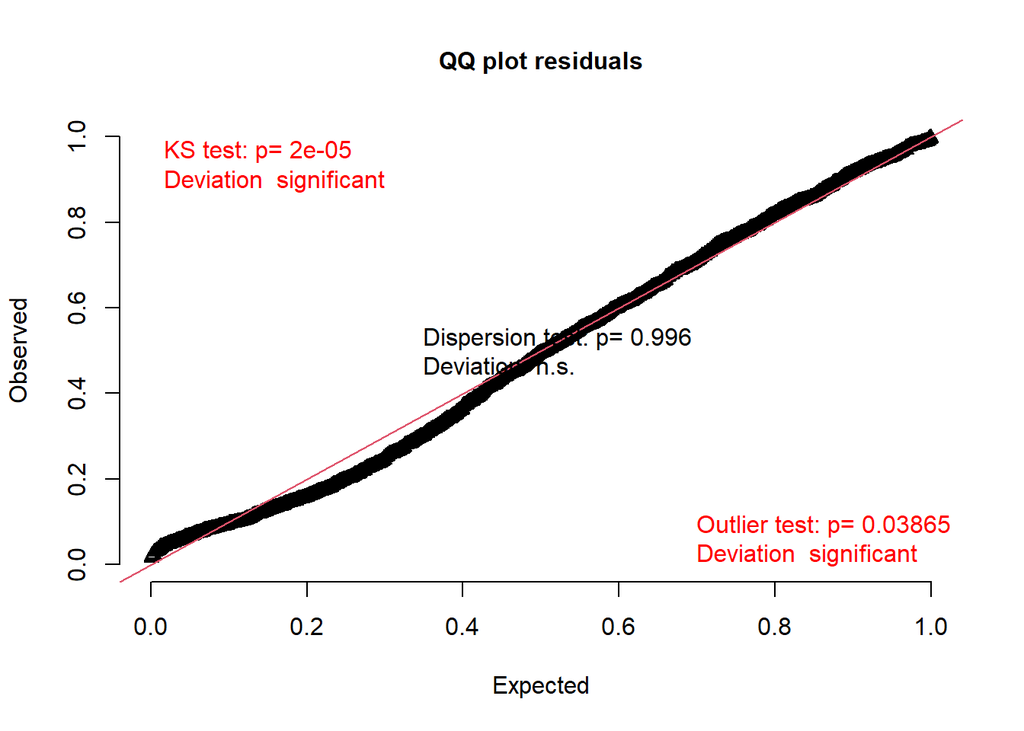

```r
diag_glmmTMB(res_tax_PD_uni$mod_full,
             "Species - PD Univariate",
             perf = FALSE)
```

```
## Diagnostics: Species - PD Univariate
```

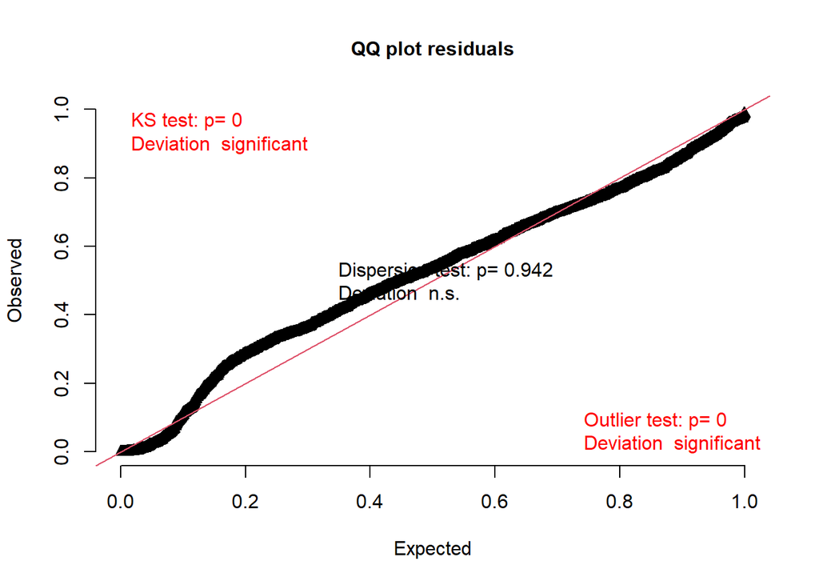

```r
# Multivariate models (collinearity assessed)
diag_glmmTMB(res_tax_shannon_multi$mod_full,
             "Species - Shannon Multivariate",
             perf = TRUE)
```

```
## Diagnostics: Species - Shannon Multivariate
```

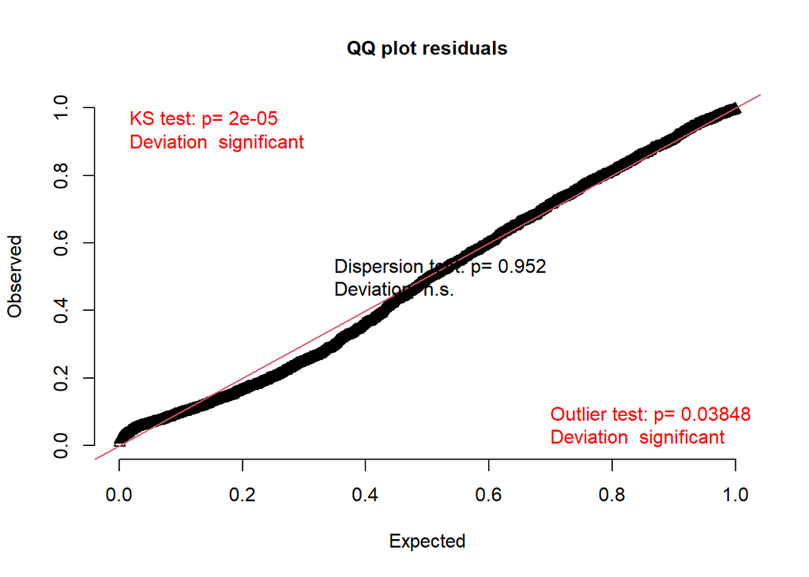

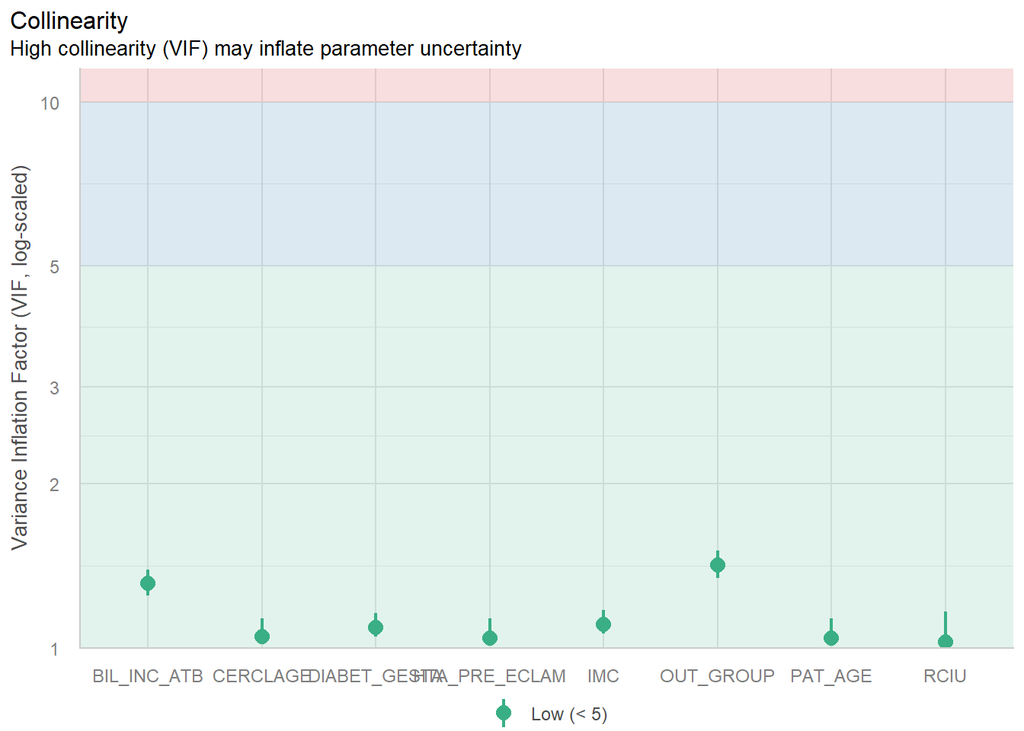

```r
diag_glmmTMB(res_tax_PD_multi$mod_full,
             "Species - PD Multivariate",
             perf = TRUE)
```

```
## Diagnostics: Species - PD Multivariate
```

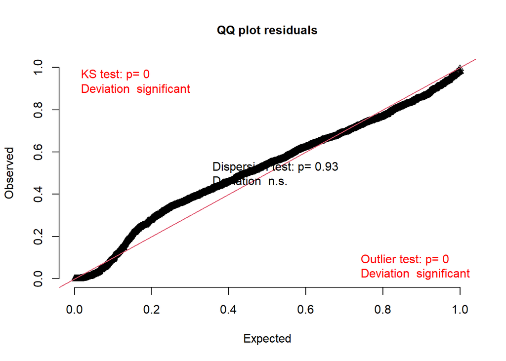

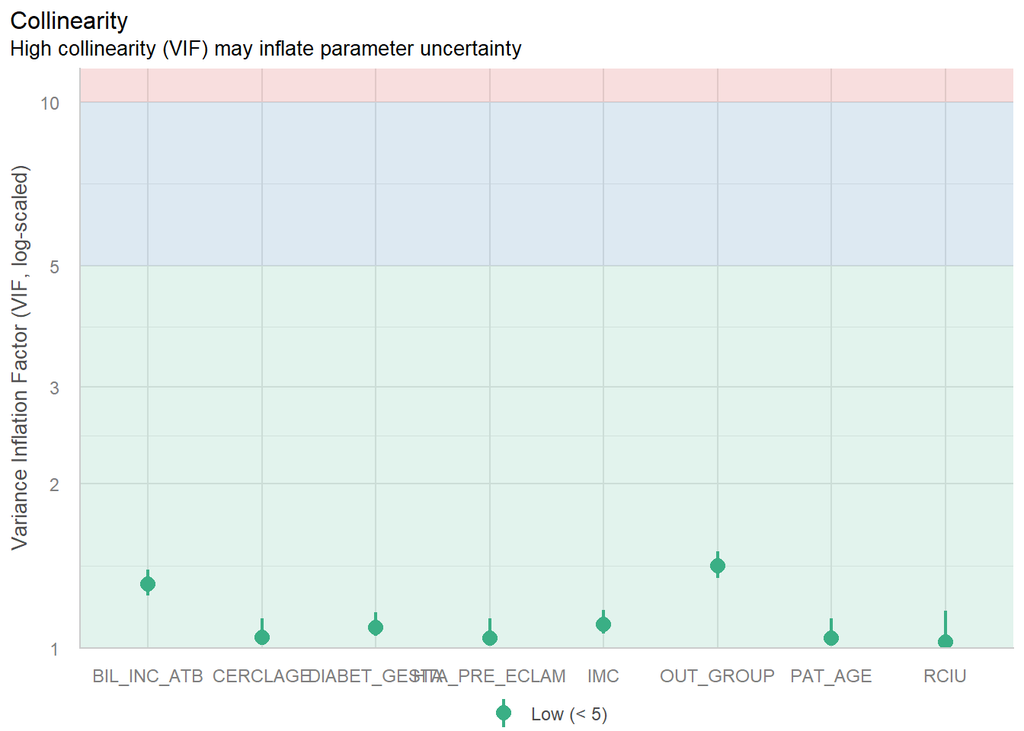

```r
# ARGs Shannon Univariate
diag_glmmTMB(res_arg_shannon_uni$mod_detection,   "ARGs - Shannon (Detection, Univariate)",   perf = FALSE)
```

```
## Diagnostics: ARGs - Shannon (Detection, Univariate)
```

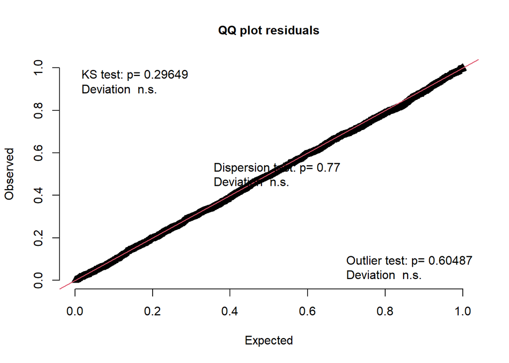

```r
diag_glmmTMB(res_arg_shannon_uni$mod_conditional, "ARGs - Shannon (Composition, Univariate)", perf = FALSE)
```

```
## Diagnostics: ARGs - Shannon (Composition, Univariate)
```

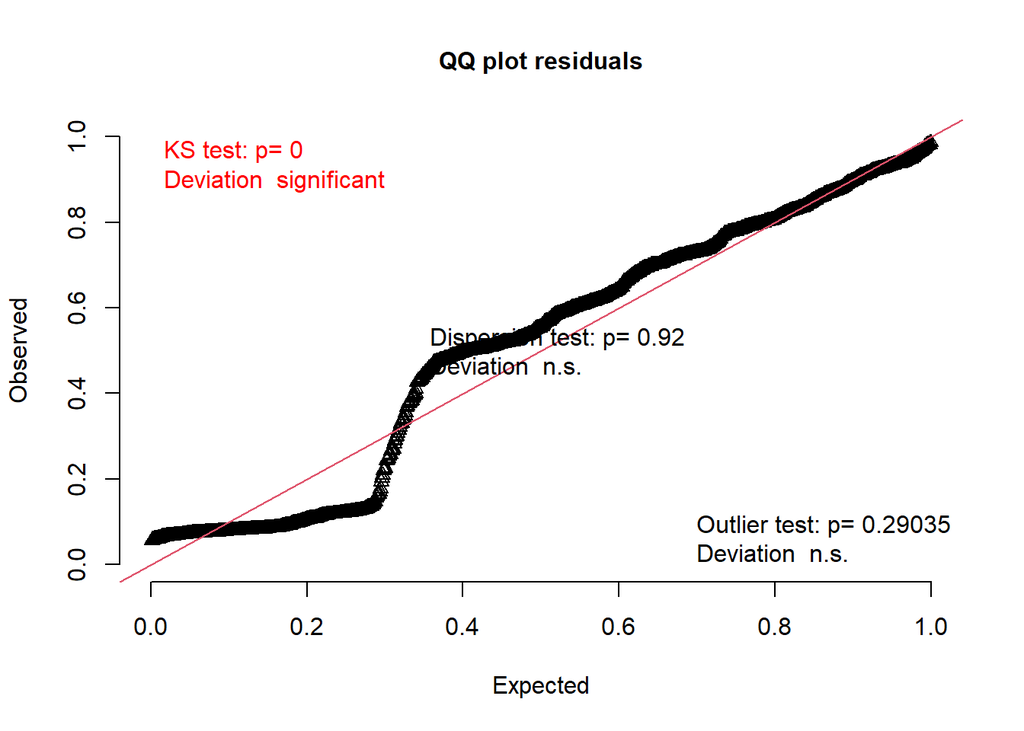

```r
# ARGs Shannon Multivariate
diag_glmmTMB(res_arg_shannon_multi$mod_detection,   "ARGs - Shannon (Detection, Multivariate)",   perf = TRUE)
```

```
## Diagnostics: ARGs - Shannon (Detection, Multivariate)
```

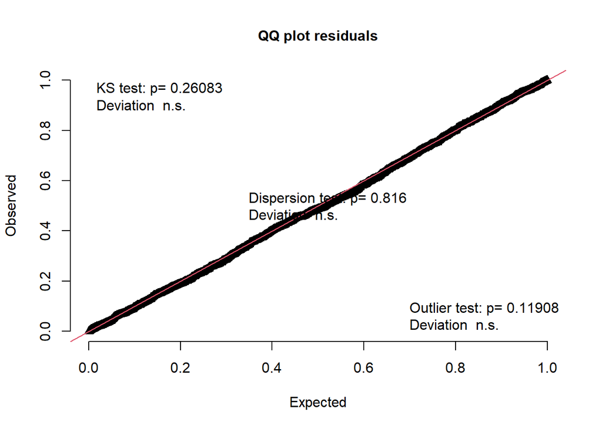

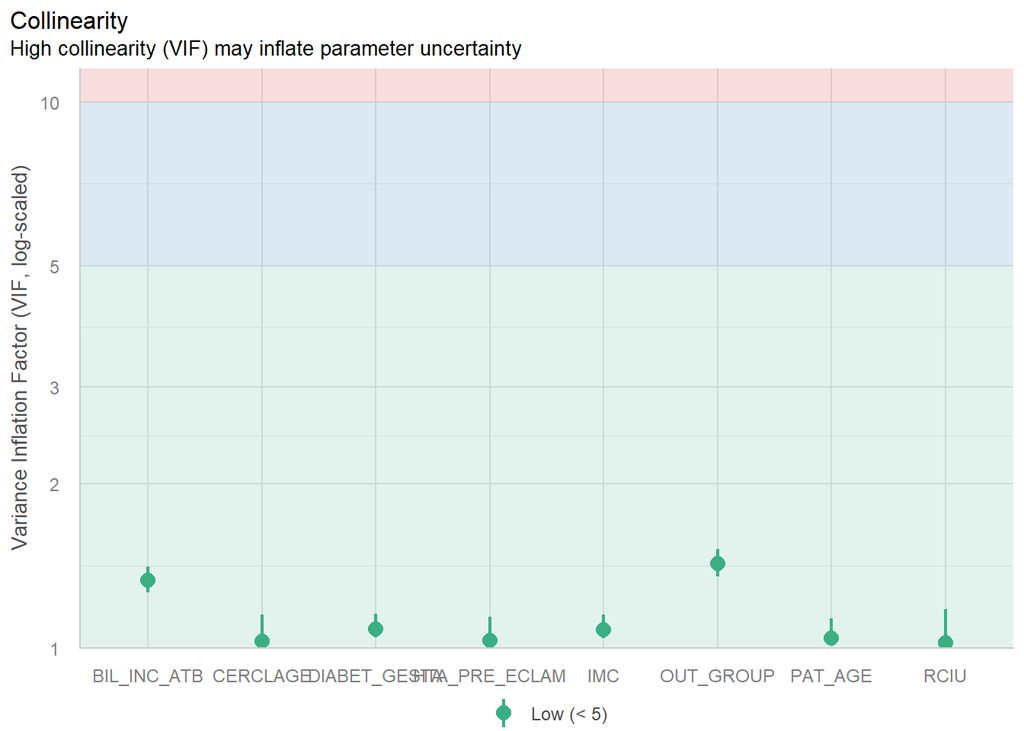

```r
diag_glmmTMB(res_arg_shannon_multi$mod_conditional, "ARGs - Shannon (Composition, Multivariate)", perf = TRUE)
```

```
## Diagnostics: ARGs - Shannon (Composition, Multivariate)
```

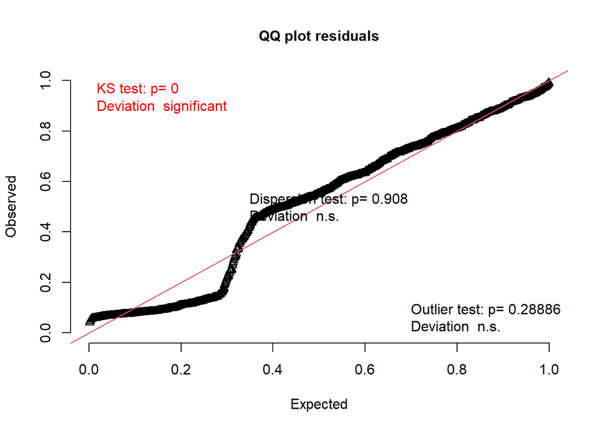

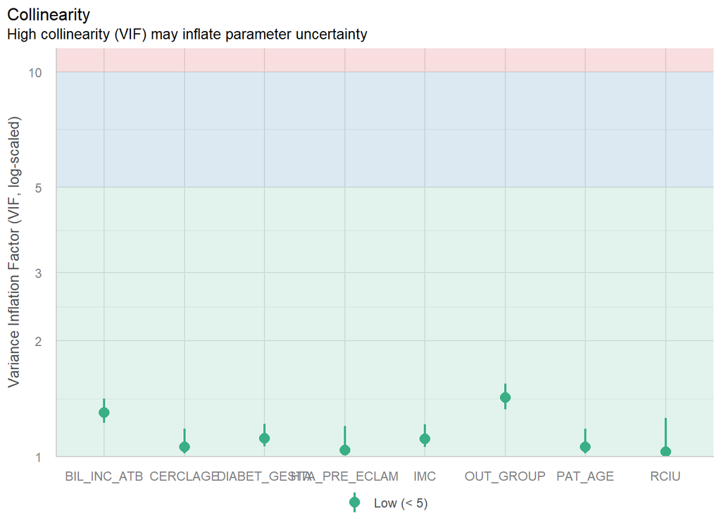

```r
# ARGs PRDI Univariate
diag_glmmTMB(res_arg_prdi_uni$mod_detection,   "ARGs - PDRI (Detection, Univariate)",   perf = FALSE)
```

```
## Diagnostics: ARGs - PDRI (Detection, Univariate)
```

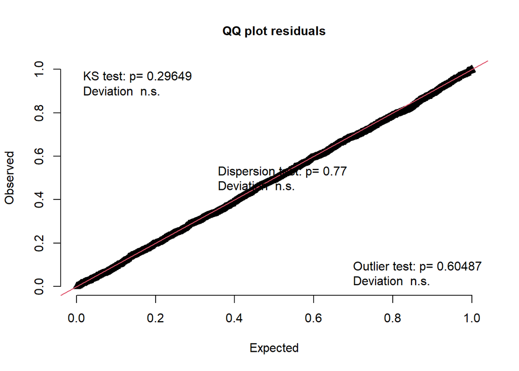

```r
diag_glmmTMB(res_arg_prdi_uni$mod_conditional, "ARGs - PDRI (Composition, Univariate)", perf = FALSE)
```

```
## Diagnostics: ARGs - PDRI (Composition, Univariate)
```

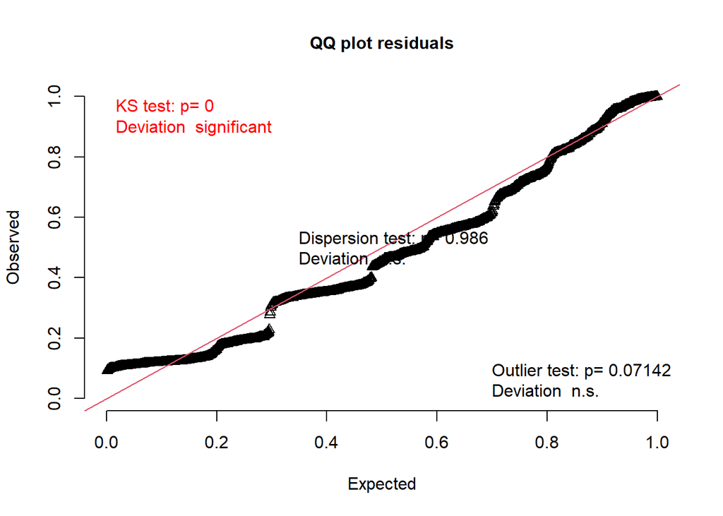

```r
# ARGs PRDI Multivariate
diag_glmmTMB(res_arg_prdi_multi$mod_detection,   "ARGs - PDRI (Detection, Multivariate)",   perf = TRUE)
```

```
## Diagnostics: ARGs - PDRI (Detection, Multivariate)
```

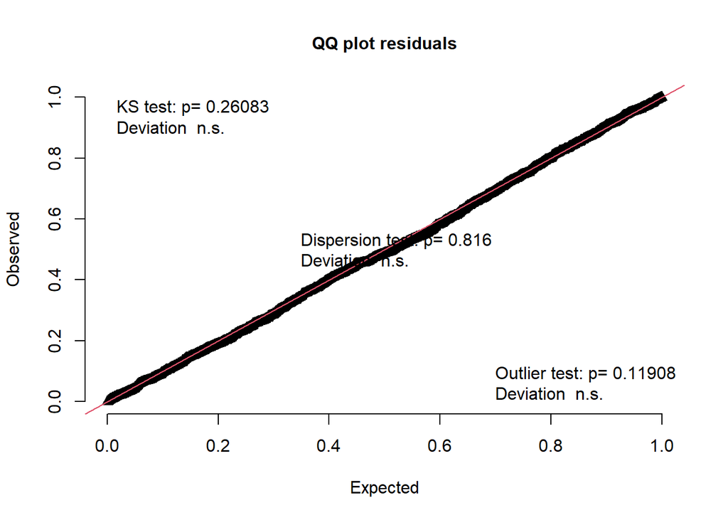

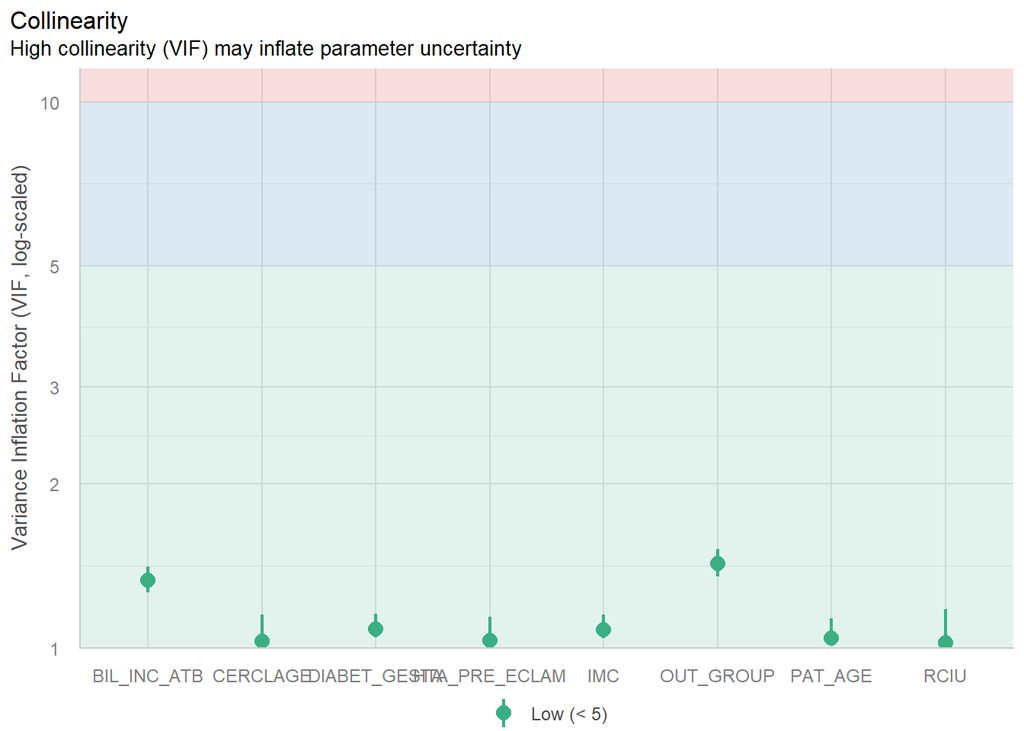

```r
diag_glmmTMB(res_arg_prdi_multi$mod_conditional, "ARGs - PDRI (Composition, Multivariate)", perf = TRUE)
```

```
## Diagnostics: ARGs - PDRI (Composition, Multivariate)
```

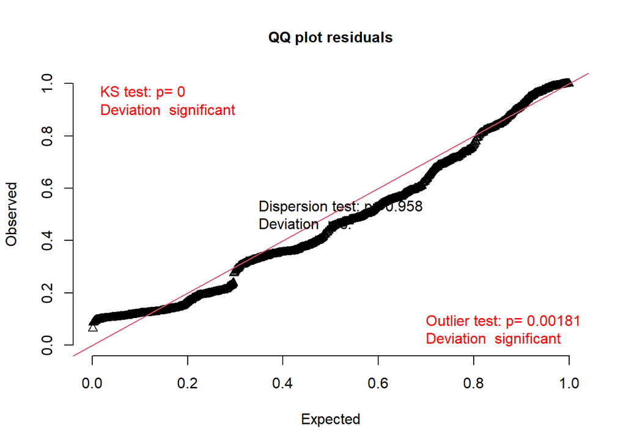

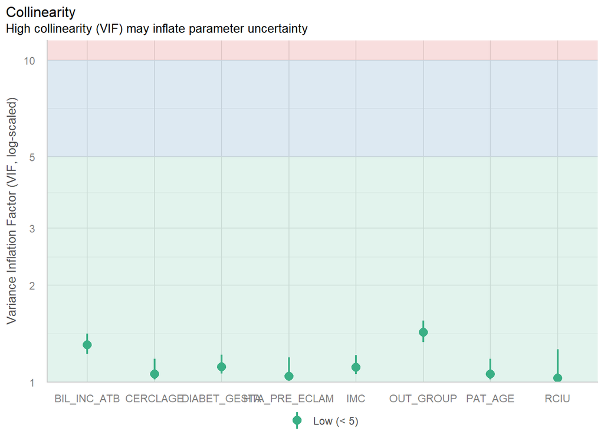

```r
# MGE Shannon Univariate
diag_glmmTMB(res_mge_shannon_uni$mod_detection,   "MGEs - Shannon (Detection, Univariate)",   perf = FALSE)
```

```
## Diagnostics: MGEs - Shannon (Detection, Univariate)
```

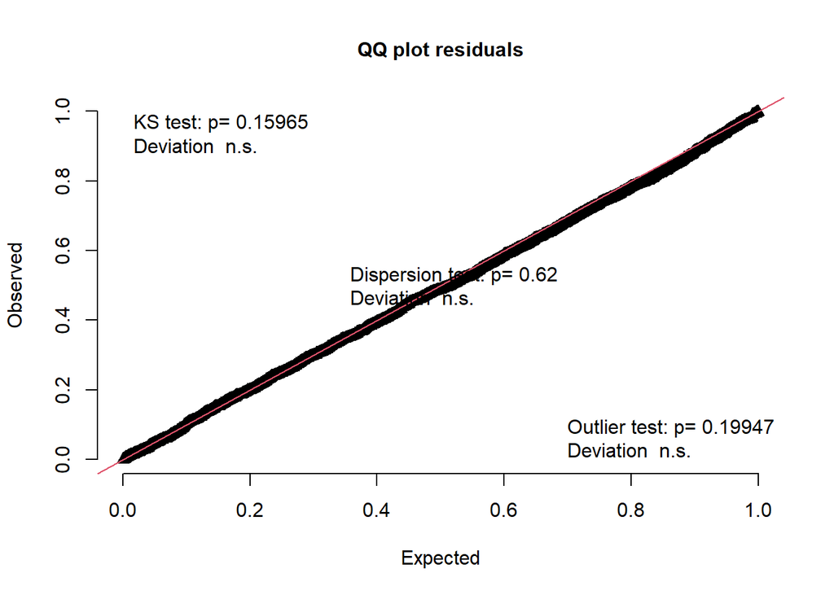

```r
diag_glmmTMB(res_mge_shannon_uni$mod_conditional, "MGEs - Shannon (Composition, Univariate)", perf = FALSE)
```

```
## Diagnostics: MGEs - Shannon (Composition, Univariate)
```

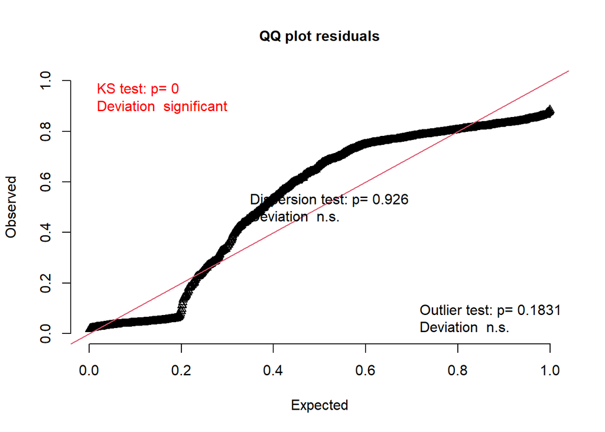

```r
# MGE Shannon Multivariate
diag_glmmTMB(res_mge_shannon_multi$mod_detection,   "MGEs - Shannon (Detection, Multivariate)",   perf = TRUE)
```

```
## Diagnostics: MGEs - Shannon (Detection, Multivariate)
```

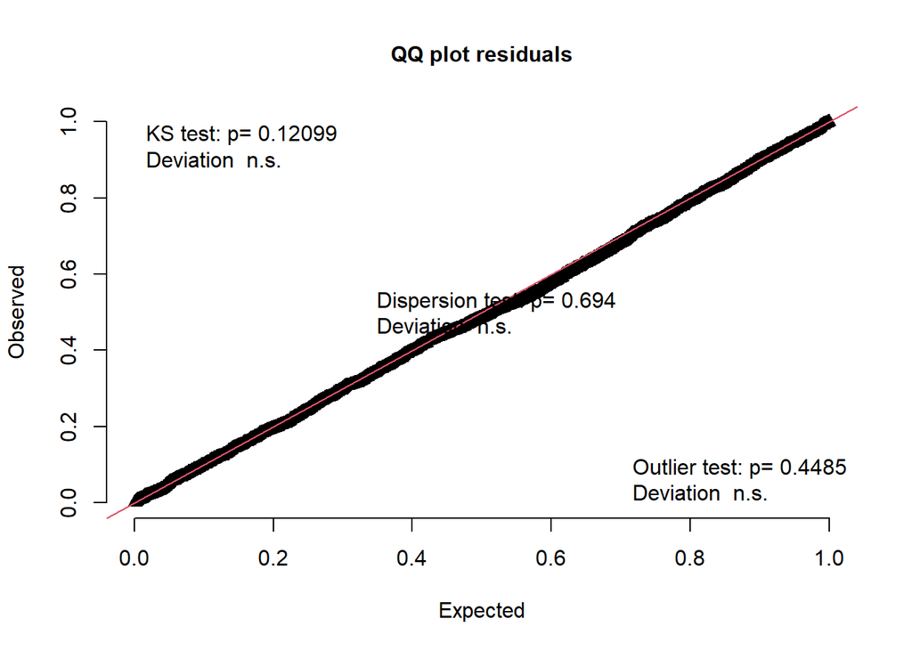

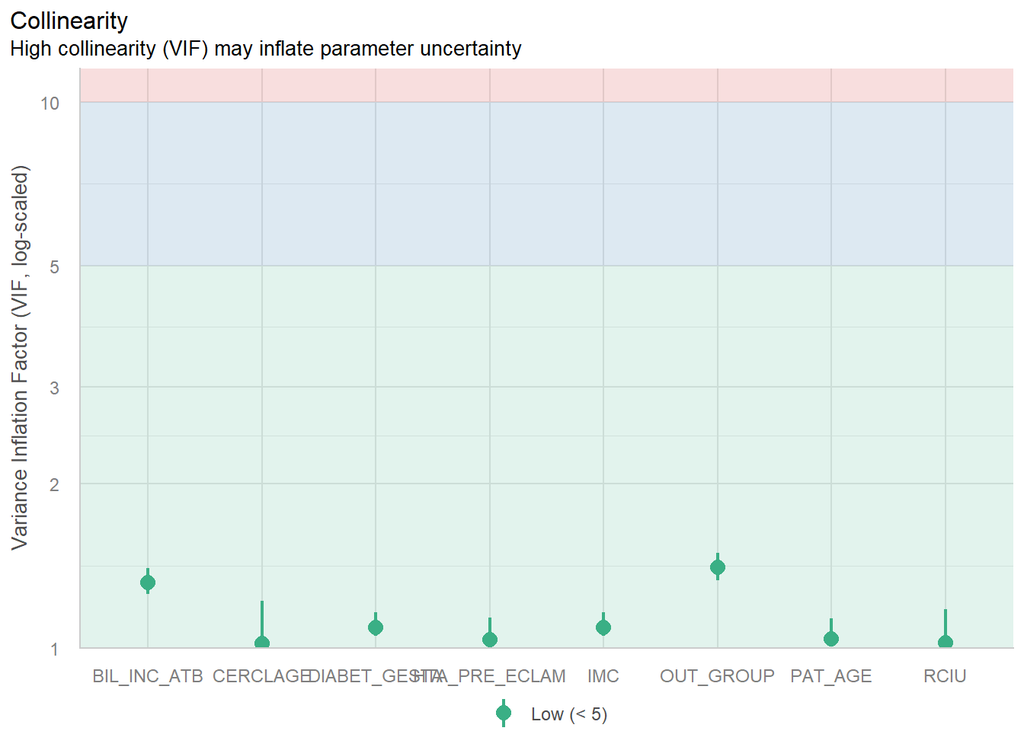

```r
diag_glmmTMB(res_mge_shannon_multi$mod_conditional, "MGEs - Shannon (Composition, Multivariate)", perf = TRUE)
```

```
## Diagnostics: MGEs - Shannon (Composition, Multivariate)
```

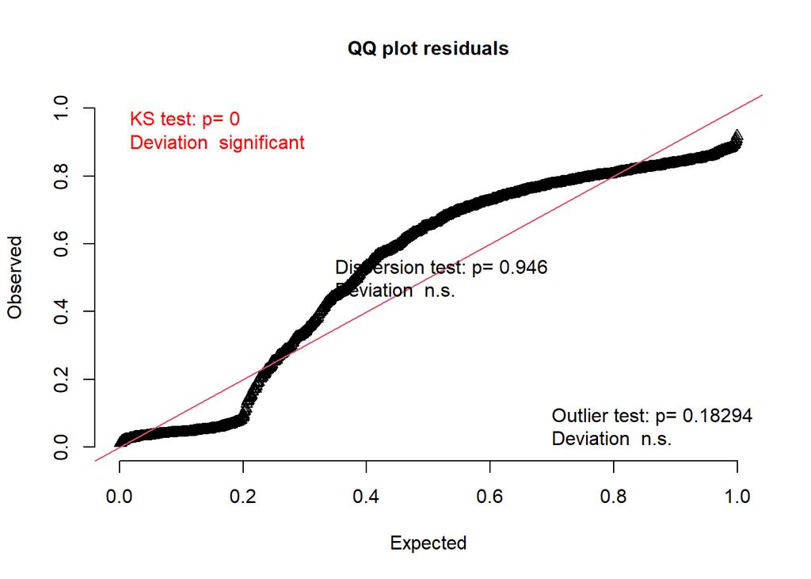

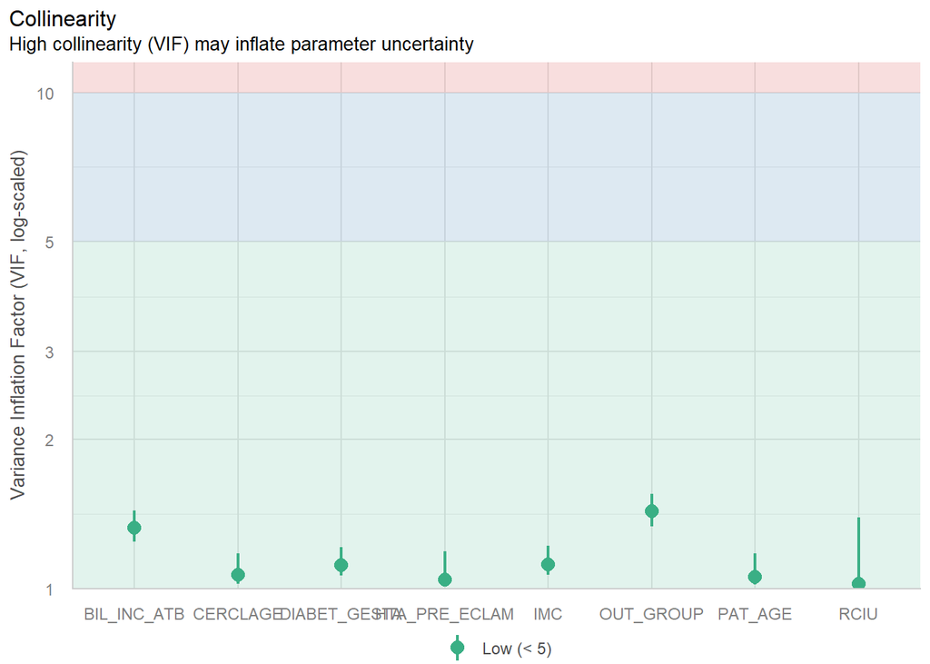

# (2) b-diversity

-> assessing compositional differences between clinical groups.

```r
# Align matrix with metadata ID
align_meta_mat <- function(mat, meta) {
  s <- intersect(rownames(mat), rownames(meta))
  list(mat = mat[s, , drop = FALSE], meta = meta[s, , drop = FALSE])}

# PERMANOVA using Adonis
adonis_analysis <- function(matrice, metadata, formula, method, by = NULL, permutations = 999) {
  dist <- vegdist(as.matrix(matrice), method = method)
  adonis2(dist ~ ., data = model.frame(formula, metadata),by = by, permutations = permutations)}

#Plot R2 results for IN and SN
plot_adonis_R2 <- function(res_IN, res_SN, title = NULL) {
  df_IN <- as.data.frame(res_IN)
  df_SN <- as.data.frame(res_SN)
  terms <- intersect(rownames(df_IN), rownames(df_SN))
  terms <- setdiff(terms, c("Residual", "Total"))
  r2 <- cbind(IN = df_IN[terms, "R2"],SN = df_SN[terms, "R2"])

  xmax <- max(r2, na.rm = TRUE) * 1.2
  op <- par(mar = c(4, 8, 4, 4))
  on.exit(par(op))

  barplot(t(r2),horiz = TRUE, beside = TRUE,
          col = c("blue", "grey"),
          xlab = "PERMANOVA R²",
          main = title,
          xlim = c(0, xmax),
          names.arg = terms,las = 2,
          legend.text = c("IN", "SN"),
          args.legend = list(bty = "n", x = "bottomright"))}
```

```r
# Split metadata by sampling type (inclusion : IN ; Delivery (SN))
metadata_IN <- metadata[metadata$Type == "IN", , drop = FALSE]
metadata_SN <- metadata[metadata$Type == "SN", , drop = FALSE]
metadata_IN <- as.data.frame(metadata_IN)
metadata_SN <- as.data.frame(metadata_SN)
rownames(metadata_IN) <- metadata_IN$SampleID
rownames(metadata_SN) <- metadata_SN$SampleID
keep_IN <- rownames(metadata_IN)
keep_SN <- rownames(metadata_SN)
Taxo_IN <- Taxo_count[rownames(Taxo_count) %in% keep_IN, , drop = FALSE]
Taxo_SN <- Taxo_count[rownames(Taxo_count) %in% keep_SN, , drop = FALSE]
ARGs_IN <- ARGs_count[rownames(ARGs_count) %in% keep_IN, , drop = FALSE]
ARGs_SN <- ARGs_count[rownames(ARGs_count) %in% keep_SN, , drop = FALSE]
MGEs_IN <- MGEs_count[rownames(MGEs_count) %in% keep_IN, , drop = FALSE]
MGEs_SN <- MGEs_count[rownames(MGEs_count) %in% keep_SN, , drop = FALSE]

# Drop empty rows, as samples without features are not informative for compositional distance analyses
# (see https://rdrr.io/cran/vegan/man/vegdist.html for more information)
Taxo_IN <- Taxo_IN[rowSums(Taxo_IN) > 0, , drop = FALSE]
ARGs_IN <- ARGs_IN[rowSums(ARGs_IN) > 0, , drop = FALSE]
MGEs_IN <- MGEs_IN[rowSums(MGEs_IN) > 0, , drop = FALSE]
Taxo_SN <- Taxo_SN[rowSums(Taxo_SN) > 0, , drop = FALSE]
ARGs_SN <- ARGs_SN[rowSums(ARGs_SN) > 0, , drop = FALSE]
MGEs_SN <- MGEs_SN[rowSums(MGEs_SN) > 0, , drop = FALSE]
```